# Gat201 RNA Seq Deseqcanalysisc 2021-04-29

Liz Hughes

29/04/2021

# GAT201 RNA Seq analysis_EHughes

To carry out RNA-Seq I will use the Lexogen Quant Seq 3’ mRNA-Seq library prep kit FWD. This is designed to generate illumina compatible libraries of sequences close to the 3’ end of polyA RNA.

Work flow: Reverse transcription ⇒ Removal of RNA ⇒ Second strand synthesis ⇒ Library amplification ⇒ Sequencing

4 strains: KN99a, KN99 alpha, Gat201 deletion from the Madhani deletion collection (003) and Gat201 disruption from the Bahn collection (004).

2 conditions: RPMI and RPMI+Serum (10%).

2 BioReps and 3 Tech Reps.

A single colony was grown in YPD, 30 degrees, 200rpm for 5 days.

3.5 ml was transferred to 100ml fresh RPMI or RPMI+10% Serum and incubated at 37 degrees, 60rpm.

2ml samples were taken from each rep at time 0hrs, fix and freeze and put at -80 degrees.

At 30 mins, 2hrs and 4hrs 15 ml samples were collected, fix and freeze and put at -80 degrees.

# Install Packages required, not need to do everytime but keeping code here for future

BiocManager::install(“biobroom”) BiocManager::install(“DESeq2”)

# Load packages used for analysis

# Define colours for specific samples

A_Y_0 = “Navy” A_R_30 = “lightblue” A_R_120 = “blue” A_R_240 = “darkblue” A_RS_30 = “lightgreen” A_RS_120 = “green” A_RS_240 = “darkgreen” a_Y_0 = “Red” a_R_30 = “darkred” a_R_120 = “magenta” a_R_240 = “darkmagenta” a_RS_30 = “lightgreen” a_RS_120 = “pink” a_RS_240 = “darkgreen” B_Y_0 = “Blue” B_R_30 = “Red” B_R_120 = “darkred” B_R_240 = “darkmagenta” B_RS_30 = “lightgreen” B_RS_120 = “green” B_RS_240 = “darkgreen” M_Y_0 = “Orange” M_R_30 = “Red” M_R_120 = “darkred” M_R_24 = “darkmagenta” M_RS_30 = “lightgreen” M_RS_120 = “green” M_RS_240 = “darkgreen”

# Load count data and remove unwanted parts of column names

```r
counts <- readr::read_tsv("~/Documents/GitHub/CryptoGat201RNASeq_draft/quantseqfwd_EH_050221/counts.txt",
                   comment = "#") %>%
          dplyr::rename_with(str_remove_all, pattern = "_S[0-9]+_R1_001_aln.bam")
```

# Load sample sheet and format for DESeq2’s requirements: readxl::read_excel

Connect sample names to informative data that generated the data.

Extra steps to format for DESeq2.

Remove all samples not sequenced: ‘dplyr::filter’

Remove notes in column: ‘dplyr::select’

Set rownames to make format of table appropriate for DESeq: ‘magrittr::set_rownames’

```r
samplesheet <- readxl::read_excel("~/Documents/GitHub/CryptoGat201RNASeq_draft/input_experiment/Gat201_samplesheet.xlsx") %>%
    magrittr::set_rownames(.$SampleID)%>%
    dplyr::mutate(GAT201 = forcats::fct_collapse(Strain, Yes = c("a","A"), No = c("B","M")))
```

We now have all the ingredients to prepare our data object in a form that is suitable for analysis, namely:

counts: a table with the read counts samplesheet: a table with information about the samples

# Select counts

Set rownames to make format of table appropriate for DESeq: ‘magrittr::set_rownames’

```r
counts_all <-
  dplyr::select(counts, samplesheet$SampleID) %>%
   magrittr::set_rownames(counts$Geneid)
```

# Construct the data object from the matrix of counts and the samplesheet information table

```r
(dds_all <- DESeqDataSetFromMatrix(countData = counts_all,
                                 colData = samplesheet,
                                 design = ~ Condition + Strain + Time))
```

```
## class: DESeqDataSet
## dim: 6795 56
## metadata(1): version
## assays(1): counts
## rownames(6795): CNAG_00002 CNAG_00003 ... CNAG_14001 CNAG_14002
## rowData names(0):
## colnames(56): 1 2 ... 55 56
## colData names(9): SampleID BioRep ... Time GAT201
```

# rlog Transformation

DESeq2 offers the regularized-logarithm transformation, or rlog for short. For genes with high counts, the rlog transformation differs not much from an ordinary log2 transformation. For genes with lower counts, however, the values are shrunken towards the genes’ averages across all samples. Using an empirical Bayesian prior on inter-sample differences in the form of a ridge penalty, this is done such that the rlog-transformed data are approximately homoskedastic.

```r
rld_all <- rlog(dds_all)
           head(assay(rld_all))
```

```
##                    1         2        3         4       5b         6        7
## CNAG_00002  8.754840 10.343840 8.823345  8.443942 8.681945 10.416515 8.834259
## CNAG_00003  7.977184  6.966253 6.575968  6.887152 7.827133  6.883900 6.800443
## CNAG_00004  8.285381  8.243997 7.579837  7.130943 8.205970  8.194406 7.367782
## CNAG_00005  9.100014  8.939314 8.764728  8.386466 8.533863  8.850015 8.937491
## CNAG_00006 10.306203  9.565392 9.937058 10.177375 9.905369  9.548736 9.979532
## CNAG_00007  7.681137  9.211125 8.620862  8.458208 7.901747  9.113592 8.683574
##                    8         9        10        11        12       13        14
## CNAG_00002  8.394622 10.253651  8.776026  8.370362 10.458688 8.957433  8.420642
## CNAG_00003  6.782918  7.197444  6.747447  6.735191  7.068382 6.667859  6.486296
## CNAG_00004  7.413073  8.189683  7.824203  7.455033  8.276967 7.588608  7.398294
## CNAG_00005  8.313652  9.170730  9.053895  8.350017  9.063553 8.916345  8.423907
## CNAG_00006 10.198612  9.723669 10.016086 10.240084  9.621604 9.952586 10.271052
## CNAG_00007  8.340636  9.334206  8.671691  8.631586  9.423569 8.883706  8.589471
##                   15        16       17        18        19        20       21
## CNAG_00002  8.933495 10.450413 8.914310  8.477705  8.930142 10.499717 8.876647
## CNAG_00003  7.850142  7.012786 6.865562  6.881818  7.489894  7.060078 6.614772
## CNAG_00004  8.091698  8.169180 7.548043  7.233457  8.163397  8.170167 7.711114
## CNAG_00005  8.901122  8.868831 8.756146  8.180595  9.104493  8.987268 8.729237
## CNAG_00006 10.102668  9.542429 9.975105 10.016891 10.342790  9.614300 9.998832
## CNAG_00007  7.881267  9.259682 8.730824  8.372927  7.763678  9.253728 8.761705
##                   22        23       24        25        26        27        28
## CNAG_00002  8.582865 10.492107 8.796192  8.387656 10.570651  9.013045  8.407413
## CNAG_00003  6.706762  7.011772 6.923658  6.578410  7.061011  6.811347  6.500275
## CNAG_00004  7.321848  8.257257 7.631595  7.418984  8.228817  7.538623  7.275987
## CNAG_00005  8.180989  9.101546 8.964531  8.356604  9.084698  8.910422  8.164935
## CNAG_00006 10.157834  9.633529 9.977944 10.122618  9.566092 10.107835 10.187882
## CNAG_00007  8.328067  9.171016 8.815515  8.564518  9.278755  8.984203  8.568854
##                  29b        30       31        32        33        34        35
## CNAG_00002  9.334531 10.405446 8.626686  8.605483  9.356104 10.411449  8.954610
## CNAG_00003  7.859369  6.845315 6.541454  6.358068  7.855819  6.936405  6.843567
## CNAG_00004  7.988498  7.883949 7.476611  7.250637  7.966506  7.931587  7.493754
## CNAG_00005  8.769806  8.892066 8.908186  8.498512  8.932057  8.911164  9.113845
## CNAG_00006 10.195925  9.614672 9.940306 10.303354 10.189526  9.607375 10.027507
## CNAG_00007  7.664435  9.337668 8.657560  8.578542  7.708854  9.230003  8.719525
##                   36        37        38        39        40        41
## CNAG_00002  8.570956 10.385430  8.956103  8.455614 10.603292  8.860934
## CNAG_00003  6.250674  7.146386  7.109772  6.433794  7.064271  7.001137
## CNAG_00004  7.232440  8.035893  7.698301  7.371792  8.236442  7.542188
## CNAG_00005  8.766402  9.710160  9.359717  8.474088  9.331626  9.627885
```

[output cut: 8 more lines]

```
## CNAG_00007  8.759327  7.646055  9.178676  8.790714  8.546172  7.736238
##                   48       49        50        51        52        53        54
## CNAG_00002 10.296873 9.109590  8.817144 10.378544  8.780898  8.448410 10.534125
## CNAG_00003  6.468055 6.995892  6.456664  6.858985  6.875372  6.401096  6.942474
## CNAG_00004  8.164158 7.713008  7.253749  8.058885  7.444963  7.326496  8.374614
## CNAG_00005  8.994491 9.315845  8.613660  9.560160  9.615240  8.624831  9.684476
## CNAG_00006  9.769690 9.948950 10.248051  9.762597 10.179798 10.430520  9.848515
## CNAG_00007  9.441023 8.660745  8.682578  9.441656  8.867592  8.735428  9.420521
##                   55        56
## CNAG_00002  8.953196  8.732771
## CNAG_00003  6.777329  6.549142
## CNAG_00004  7.531828  7.331251
## CNAG_00005  9.540064  8.713476
## CNAG_00006 10.110537 10.439966
## CNAG_00007  8.897945  8.790893
```

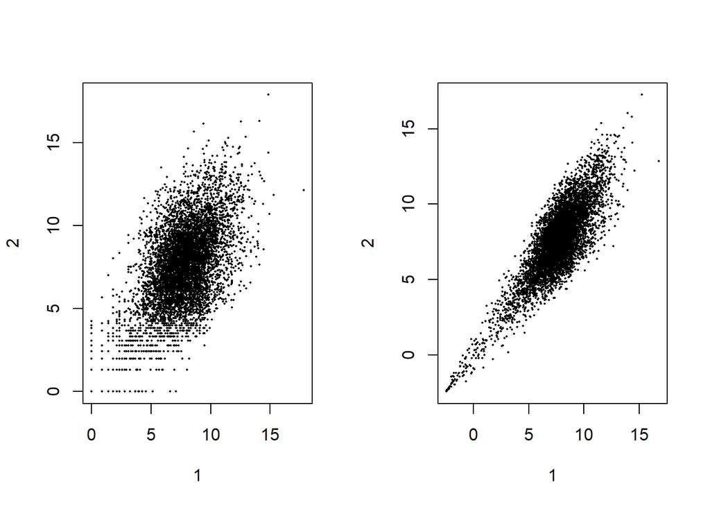

```r
par( mfrow = c( 1, 2 ) )
dds <- estimateSizeFactors(dds_all)
plot(log2( 1 + counts(dds, normalized=TRUE)[ , 1:2] ),
     pch=16, cex=0.3)
plot(assay(rld_all)[ , 1:2],
     pch=16, cex=0.3)
```

We can see how genes with low counts seem to be excessively variable on the ordinary logarithmic scale, while the rlog transform compresses differences for genes for which the data cannot provide good information anyway.

# Sample distances

A useful first step in an RNA-Seq analysis is often to assess overall similarity between samples: Which samples are similar to each other, which are different? Does this fit to the expectation from the experiment’s design?

We use the R function dist to calculate the Euclidean distance between samples. To avoid that the distance measure is dominated by a few highly variable genes, and have a roughly equal contribution from all genes, we use it on the rlog-transformed data.

Note the use of the function t to transpose the data matrix. We need this because dist calculates distances between data rows and our samples constitute the columns.

```r
sampleDists_all <- dist( t( assay(rld_all) ) )
```

# Heatmap

We visualize the distances in a heatmap, using the function pheatmap from the pheatmap package. In order to plot the sample distance matrix with the rows/columns arranged by those distances in the matrix, we manually provide the sampleDists to the clustering_distance argument of the pheatmap function. Otherwise the pheatmap function would assume that the matrix contains the data values themselves, and would calculate distances between the rows/columns of the distance matrix, which is not desired.

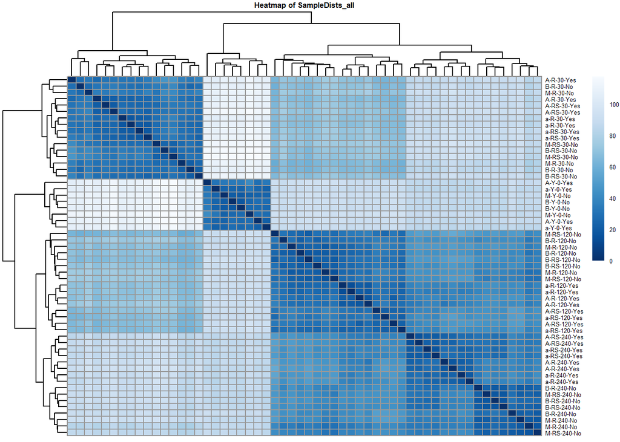

```r
sampleDistMatrix <- as.matrix(sampleDists_all)
rownames(sampleDistMatrix) <- paste( rld_all$Strain, rld_all$Condition, rld_all$Time, rld_all$GAT201, sep="-" )
colnames(sampleDistMatrix) <- NULL
colors <- colorRampPalette( rev(brewer.pal(9, "Blues")) )(255)
pheatmap(sampleDistMatrix,
         clustering_distance_rows=sampleDists_all,
         clustering_distance_cols=sampleDists_all,
         col=colors, cex = 0.7,
         main = "Heatmap of SampleDists_all")
```

## Prepare similar Heatmaps for each timepoint.

## Heatmap 0hrs

```r
samplesheet_0h <-  dplyr::filter(samplesheet, Time == "0")
                  print(samplesheet_0h)
```

```
## # A tibble: 8 x 9
##   SampleID BioRep Media Timepoint Group Strain Condition  Time GAT201
## * <chr>     <dbl> <chr>     <dbl> <chr> <chr>  <chr>     <dbl> <fct>
## 1 1             1 YPD           0 A_Y_0 A      Y             0 Yes
## 2 5b            2 YPD           0 A_Y_0 A      Y             0 Yes
## 3 15            1 YPD           0 a_Y_0 a      Y             0 Yes
## 4 19            2 YPD           0 a_Y_0 a      Y             0 Yes
## 5 29b           1 YPD           0 B_Y_0 B      Y             0 No
## 6 33            2 YPD           0 B_Y_0 B      Y             0 No
## 7 43            1 YPD           0 M_Y_0 M      Y             0 No
## 8 47            2 YPD           0 M_Y_0 M      Y             0 No
```

```r
counts_0h <-  dplyr::select(counts_all, samplesheet_0h$SampleID) %>%
              magrittr::set_rownames(counts$Geneid)

(dds0h <- DESeqDataSetFromMatrix(countData = counts_0h,
                                 colData = samplesheet_0h,
                                 design = ~ Strain))
```

```
## class: DESeqDataSet
## dim: 6795 8
## metadata(1): version
## assays(1): counts
## rownames(6795): CNAG_00002 CNAG_00003 ... CNAG_14001 CNAG_14002
## rowData names(0):
## colnames(8): 1 5b ... 43 47
## colData names(9): SampleID BioRep ... Time GAT201
```

```r
rld_0h <- rlog(dds0h)
          head(assay(rld_0h))
```

```
##                    1       5b       15        19      29b       33        43
## CNAG_00002  8.310850 8.263697 8.477810  8.456657 8.841835 8.859004  8.860794
## CNAG_00003  8.024874 7.915471 7.932968  7.645861 7.943076 7.937155  7.872716
## CNAG_00004  8.083642 8.019037 7.930204  7.971549 7.851502 7.830604  7.797457
## CNAG_00005  8.713546 8.240843 8.543233  8.705684 8.435022 8.571664  8.628909
## CNAG_00006 10.016824 9.674571 9.843524 10.037408 9.929192 9.920404 10.033098
## CNAG_00007  6.599582 6.794358 6.779894  6.668403 6.590875 6.630083  6.547081
##                  47
## CNAG_00002 8.645419
## CNAG_00003 8.008304
## CNAG_00004 8.027590
## CNAG_00005 8.513812
## CNAG_00006 9.817627
## CNAG_00007 6.640886
```

```r
sampleDists_0h <- dist( t( assay(rld_0h) ) )
                  head(sampleDists_0h)
```

```
## [1] 20.23555 17.15471 14.85083 20.43792 19.13045 20.37405
```

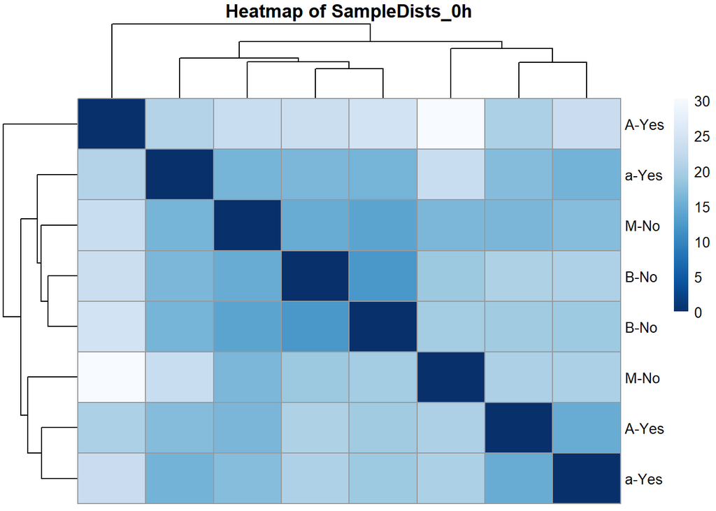

```r
sampleDistMatrix_0h <- as.matrix( sampleDists_0h )
                       rownames(sampleDistMatrix_0h) <- paste( rld_0h$Strain, rld_0h$GAT201, sep="-" )
                       colnames(sampleDistMatrix_0h) <- NULL

colors <- colorRampPalette( rev(brewer.pal(9, "Blues")) )(255)

pheatmap(sampleDistMatrix_0h,
         clustering_distance_rows=sampleDists_0h,
         clustering_distance_cols=sampleDists_0h,
         col=colors, cex = 1,
         main = "Heatmap of SampleDists_0h")
```

## Heatmap 30min

```r
samplesheet_30m <- dplyr::filter(samplesheet, Time == "30")
                   print(samplesheet_30m)
```

```
## # A tibble: 16 x 9
##    SampleID BioRep Media  Timepoint Group   Strain Condition  Time GAT201
##  * <chr>     <dbl> <chr>      <dbl> <chr>   <chr>  <chr>     <dbl> <fct>
##  1 2             1 RPMI          30 A_R_30  A      R            30 Yes
##  2 6             2 RPMI          30 A_R_30  A      R            30 Yes
##  3 9             1 RPMI+S        30 A_RS_30 A      RS           30 Yes
##  4 12            2 RPMI+S        30 A_RS_30 A      RS           30 Yes
##  5 16            1 RPMI          30 a_R_30  a      R            30 Yes
##  6 20            2 RPMI          30 a_R_30  a      R            30 Yes
##  7 23            1 RPMI+S        30 a_RS_30 a      RS           30 Yes
##  8 26            2 RPMI+S        30 a_RS_30 a      RS           30 Yes
##  9 30            1 RPMI          30 B_R_30  B      R            30 No
## 10 34            2 RPMI          30 B_R_30  B      R            30 No
## 11 37            1 RPMI+S        30 B_RS_30 B      RS           30 No
## 12 40            2 RPMI+S        30 B_RS_30 B      RS           30 No
## 13 44            1 RPMI          30 M_R_30  M      R            30 No
## 14 48            2 RPMI          30 M_R_30  M      R            30 No
## 15 51            1 RPMI+S        30 M_RS_30 M      RS           30 No
## 16 54            2 RPMI+S        30 M_RS_30 M      RS           30 No
```

```r
counts_30m <- dplyr::select(counts, samplesheet_30m$SampleID) %>%
              magrittr::set_rownames(counts$Geneid)

(dds30m <- DESeqDataSetFromMatrix(countData = counts_30m,
                                 colData = samplesheet_30m,
                                 design = ~ Condition + Strain))
```

```
## class: DESeqDataSet
## dim: 6795 16
## metadata(1): version
## assays(1): counts
## rownames(6795): CNAG_00002 CNAG_00003 ... CNAG_14001 CNAG_14002
## rowData names(0):
## colnames(16): 2 6 ... 51 54
## colData names(9): SampleID BioRep ... Time GAT201
```

```r
rld_30m <- rlog(dds30m)
           head(assay(rld_30m))
```

```
##                    2         6         9        12        16        20
## CNAG_00002 10.657958 10.737521 10.567985 10.738905 10.734054 10.776531
## CNAG_00003  6.716080  6.665360  6.892073  6.785677  6.740890  6.780224
## CNAG_00004  8.192009  8.166525  8.131787  8.204681  8.114564  8.115387
## CNAG_00005  8.821959  8.759596  9.013428  8.915430  8.746632  8.850054
## CNAG_00006  9.085081  9.085746  9.225924  9.123962  9.048605  9.119036
## CNAG_00007  9.252795  9.186078  9.344777  9.420718  9.280394  9.275219
##                   23        26        30        34        37        40
## CNAG_00002 10.760260 10.829880 10.706495 10.733548 10.675736 10.868409
## CNAG_00003  6.732985  6.773720  6.618456  6.707300  6.852859  6.784981
## CNAG_00004  8.180674  8.158185  7.888678  7.946346  7.997546  8.174433
## CNAG_00005  8.942357  8.929565  8.777208  8.814100  9.507258  9.161468
## CNAG_00006  9.128566  9.064632  9.129574  9.143744  9.254591  9.205591
## CNAG_00007  9.194729  9.289642  9.358518  9.286591  9.332754  9.346709
##                   44        48        51        54
## CNAG_00002 10.808916 10.609178 10.670968 10.775747
## CNAG_00003  6.469409  6.342164  6.615087  6.659499
## CNAG_00004  8.119291  8.115177  8.018189  8.262715
## CNAG_00005  8.736136  8.861968  9.368661  9.453316
## CNAG_00006  9.105480  9.275480  9.263964  9.319670
## CNAG_00007  9.231711  9.442551  9.437506  9.390531
```

```r
sampleDists_30m <- dist( t( assay(rld_30m) ) )
           head(sampleDists_30m)
```

```
## [1] 19.43640 14.38004 15.11612 16.96991 15.45479 17.30166
```

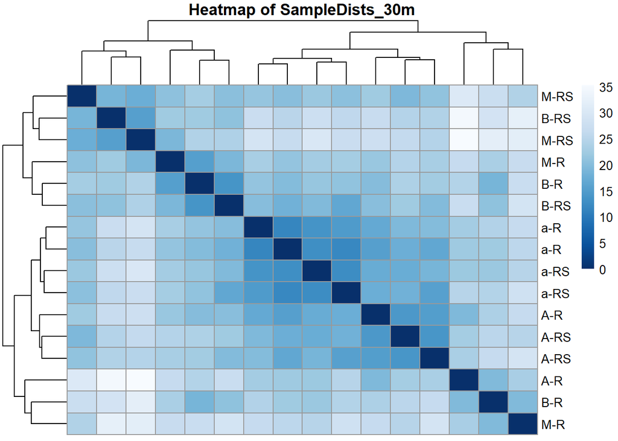

```r
sampleDistMatrix_30m <- as.matrix( sampleDists_30m )
          rownames(sampleDistMatrix_30m) <- paste( rld_30m$Strain, rld_30m$Condition, sep="-" )
          colnames(sampleDistMatrix_30m) <- NULL

colors <- colorRampPalette( rev(brewer.pal(9, "Blues")) )(255)

pheatmap(sampleDistMatrix_30m,
         clustering_distance_rows=sampleDists_30m,
         clustering_distance_cols=sampleDists_30m,
         col=colors, cex = 1,
         main = "Heatmap of SampleDists_30m")
```

## Heatmap 2hrs

```r
samplesheet_2h <- dplyr::filter(samplesheet, Time == "120")
                  print(samplesheet_2h)
```

```
## # A tibble: 16 x 9
##    SampleID BioRep Media  Timepoint Group    Strain Condition  Time GAT201
##  * <chr>     <dbl> <chr>      <dbl> <chr>    <chr>  <chr>     <dbl> <fct>
##  1 3             1 RPMI         120 A_R_120  A      R           120 Yes
##  2 7             2 RPMI         120 A_R_120  A      R           120 Yes
##  3 10            1 RPMI+S       120 A_RS_120 A      RS          120 Yes
##  4 13            2 RPMI+S       120 A_RS_120 A      RS          120 Yes
##  5 17            1 RPMI         120 a_R_120  a      R           120 Yes
##  6 21            2 RPMI         120 a_R_120  a      R           120 Yes
##  7 24            1 RPMI+S       120 a_RS_120 a      RS          120 Yes
##  8 27            2 RPMI+S       120 a_RS_120 a      RS          120 Yes
##  9 31            1 RPMI         120 B_R_120  B      R           120 No
## 10 35            2 RPMI         120 B_R_120  B      R           120 No
## 11 38            1 RPMI+S       120 B_RS_120 B      RS          120 No
## 12 41            2 RPMI+S       120 B_RS_120 B      RS          120 No
## 13 45            1 RPMI         120 M_R_120  M      R           120 No
## 14 49            2 RPMI         120 M_R_120  M      R           120 No
## 15 52            1 RPMI+S       120 M_RS_120 M      RS          120 No
## 16 55            2 RPMI+S       120 M_RS_120 M      RS          120 No
```

```r
counts_2h <-   dplyr::select(counts, samplesheet_2h$SampleID) %>%
               magrittr::set_rownames(counts$Geneid)

(dds2h <- DESeqDataSetFromMatrix(countData = counts_2h,
                                 colData = samplesheet_2h,
                                 design = ~ Condition + Strain))
```

```
## class: DESeqDataSet
## dim: 6795 16
## metadata(1): version
## assays(1): counts
## rownames(6795): CNAG_00002 CNAG_00003 ... CNAG_14001 CNAG_14002
## rowData names(0):
## colnames(16): 3 7 ... 52 55
## colData names(9): SampleID BioRep ... Time GAT201
```

```r
rld_2h <- rlog(dds2h)
          head(assay(rld_2h))
```

```
##                    3         7        10        13        17        21
## CNAG_00002  8.913283  8.925892  8.874921  9.051620  9.003939  8.967525
## CNAG_00003  6.876860  7.048756  7.010908  6.959339  7.102839  6.907349
## CNAG_00004  7.792114  7.617407  8.007707  7.811263  7.769742  7.908889
## CNAG_00005  9.243514  9.392400  9.496407  9.386523  9.239701  9.216795
## CNAG_00006 10.263883 10.304570 10.341364 10.291582 10.303122 10.323805
## CNAG_00007  8.978433  9.035168  9.028539  9.221261  9.078787  9.105182
##                   24        27        31        35        38        41
## CNAG_00002  8.895640  9.108812  8.744805  9.052360  9.050752  8.965768
## CNAG_00003  7.148552  7.069717  6.865692  7.094414  7.303754  7.227025
## CNAG_00004  7.842385  7.773053  7.720157  7.732147  7.905017  7.775954
## CNAG_00005  9.421553  9.383862  9.380934  9.557205  9.771810 10.020500
## CNAG_00006 10.308563 10.436139 10.283083 10.360729 10.350449 10.461115
## CNAG_00007  9.155793  9.315414  9.026073  9.078383  9.058636  9.280351
##                   45        49        52        55
## CNAG_00002  9.018026  9.188393  8.874152  9.045439
## CNAG_00003  7.018488  7.208098  7.107713  7.037792
## CNAG_00004  7.763919  7.911248  7.678515  7.761405
## CNAG_00005  9.676631  9.724271  9.990221  9.930426
## CNAG_00006 10.432643 10.278288 10.485331 10.431654
## CNAG_00007  9.130991  9.016032  9.195893  9.231520
```

```r
sampleDists_2h <- dist( t( assay(rld_2h) ) )
                  head(sampleDists_2h)
```

```
## [1] 12.52485 14.78573 20.07939 14.21135 14.45495 17.73962
```

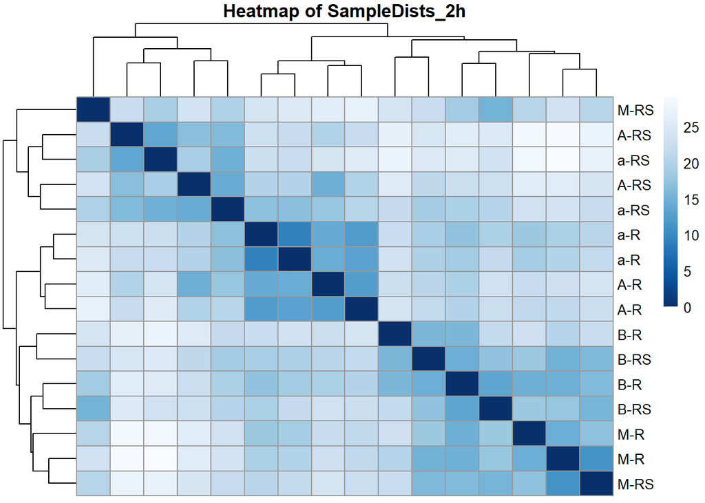

```r
sampleDistMatrix_2h <- as.matrix( sampleDists_2h )
                      rownames(sampleDistMatrix_2h) <- paste( rld_2h$Strain, rld_2h$Condition, sep="-" )
                      colnames(sampleDistMatrix_2h) <- NULL

colors <- colorRampPalette( rev(brewer.pal(9, "Blues")) )(255)

pheatmap(sampleDistMatrix_2h,
         clustering_distance_rows=sampleDists_2h,
         clustering_distance_cols=sampleDists_2h,
         col=colors, cex = 1,
         main = "Heatmap of SampleDists_2h")
```

## Heatmap 4hrs

```r
samplesheet_4h <- dplyr::filter(samplesheet, Time == "240")
                  print(samplesheet_4h)
```

```
## # A tibble: 16 x 9
##    SampleID BioRep Media  Timepoint Group    Strain Condition  Time GAT201
##  * <chr>     <dbl> <chr>      <dbl> <chr>    <chr>  <chr>     <dbl> <fct>
##  1 4             1 RPMI         240 A_R_240  A      R           240 Yes
##  2 8             2 RPMI         240 A_R_240  A      R           240 Yes
##  3 11            1 RPMI+S       240 A_RS_240 A      RS          240 Yes
##  4 14            2 RPMI+S       240 A_RS_240 A      RS          240 Yes
##  5 18            1 RPMI         240 a_R_240  a      R           240 Yes
##  6 22            2 RPMI         240 a_R_240  a      R           240 Yes
##  7 25            1 RPMI+S       240 a_RS_240 a      RS          240 Yes
##  8 28            2 RPMI+S       240 a_RS_240 a      RS          240 Yes
##  9 32            1 RPMI         240 B_R_240  B      R           240 No
## 10 36            2 RPMI         240 B_R_240  B      R           240 No
## 11 39            1 RPMI+S       240 B_RS_240 B      RS          240 No
## 12 42            2 RPMI+S       240 B_RS_240 B      RS          240 No
## 13 46            1 RPMI         240 M_R_240  M      R           240 No
## 14 50            2 RPMI         240 M_R_240  M      R           240 No
## 15 53            1 RPMI+S       240 M_RS_240 M      RS          240 No
## 16 56            2 RPMI+S       240 M_RS_240 M      RS          240 No
```

```r
counts_4h <-   dplyr::select(counts, samplesheet_4h$SampleID) %>%
               magrittr::set_rownames(counts$Geneid)

(dds4h <- DESeqDataSetFromMatrix(countData = counts_4h,
                                 colData = samplesheet_4h,
                                 design = ~ Condition + Strain))
```

```
## class: DESeqDataSet
## dim: 6795 16
## metadata(1): version
## assays(1): counts
## rownames(6795): CNAG_00002 CNAG_00003 ... CNAG_14001 CNAG_14002
## rowData names(0):
## colnames(16): 4 8 ... 53 56
## colData names(9): SampleID BioRep ... Time GAT201
```

```r
rld_4h <- rlog(dds4h)
          head(assay(rld_4h))
```

```
##                    4         8        11        14        18        22
## CNAG_00002  8.147084  8.107619  8.069060  8.116080  8.187435  8.311200
## CNAG_00003  6.814581  6.737280  6.686891  6.479004  6.812582  6.682544
## CNAG_00004  7.091310  7.347479  7.372701  7.317084  7.184426  7.275698
## CNAG_00005  8.329703  8.273600  8.294102  8.357718  8.144886  8.158236
## CNAG_00006 10.542648 10.573750 10.595896 10.617233 10.410908 10.547314
## CNAG_00007  8.613672  8.523438  8.766248  8.722827  8.545833  8.520754
##                   25        28        32        36        39        42
## CNAG_00002  8.081402  8.102249  8.312136  8.287473  8.149364  8.355644
## CNAG_00003  6.550909  6.490156  6.387222  6.303709  6.435155  6.465591
## CNAG_00004  7.332216  7.208884  7.194037  7.185617  7.290743  7.281805
## CNAG_00005  8.294287  8.118595  8.434351  8.699163  8.401713  8.498137
## CNAG_00006 10.487192 10.544152 10.653251 10.826984 10.755367 10.735714
## CNAG_00007  8.699672  8.704070  8.720325  9.048110  8.901501  8.862716
##                   46        50        53        56
## CNAG_00002  8.236146  8.526692  8.132223  8.434819
## CNAG_00003  6.547927  6.455704  6.400621  6.527716
## CNAG_00004  7.162900  7.192179  7.241898  7.256568
## CNAG_00005  8.709067  8.540205  8.533591  8.629616
## CNAG_00006 10.677687 10.599298 10.744074 10.763950
## CNAG_00007  8.687624  8.809318  8.840650  8.902125
```

```r
sampleDists_4h <- dist( t( assay(rld_4h) ) )
                  head(sampleDists_4h)
```

```
## [1] 12.87664 17.36676 18.90685 14.80330 17.45779 20.97262
```

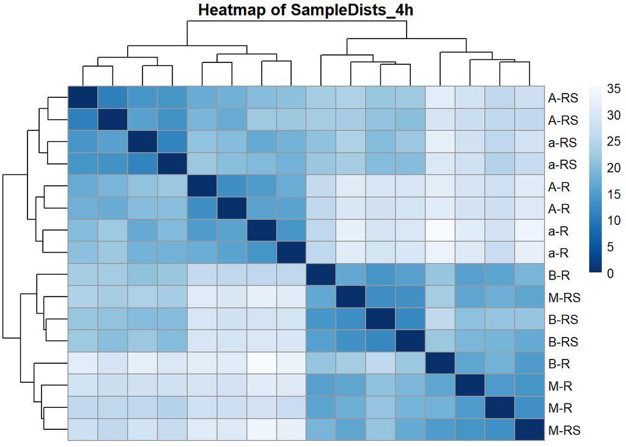

```r
sampleDistMatrix_4h <- as.matrix( sampleDists_4h )
                      rownames(sampleDistMatrix_4h) <- paste( rld_4h$Strain, rld_4h$Condition, sep="-" )
                      colnames(sampleDistMatrix_4h) <- NULL

colors <- colorRampPalette( rev(brewer.pal(9, "Blues")) )(255)

pheatmap(sampleDistMatrix_4h,
         clustering_distance_rows=sampleDists_4h,
         clustering_distance_cols=sampleDists_4h,
         col=colors, cex = 1,
         main = "Heatmap of SampleDists_4h")
```

# PCA Plot

## Plot PCA for 0h

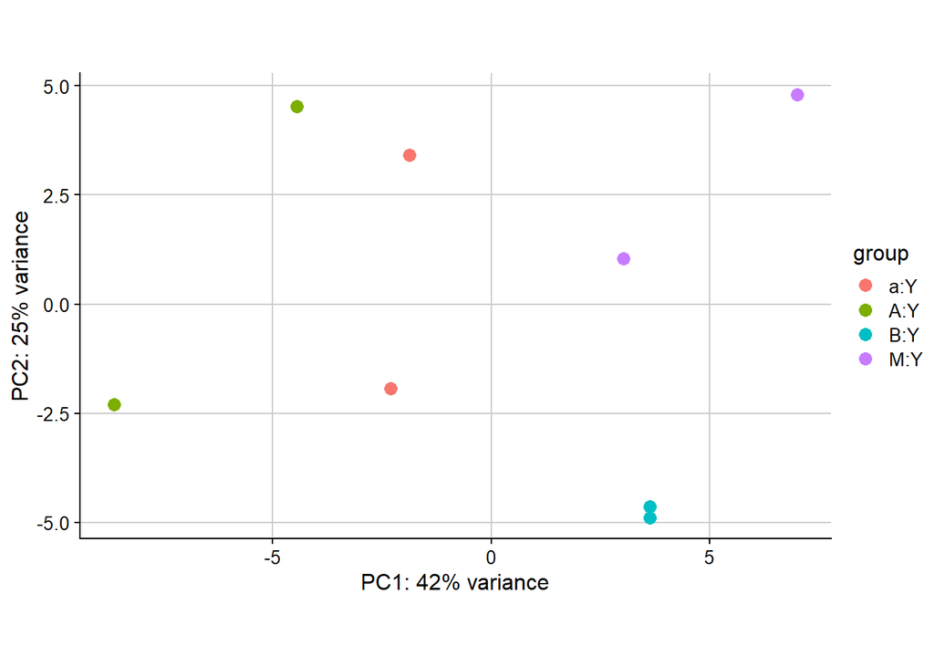

```r
plotPCA(rld_0h, intgroup = c("Strain", "Condition"))
```

How to add a title?

## Plot PCA for 30min

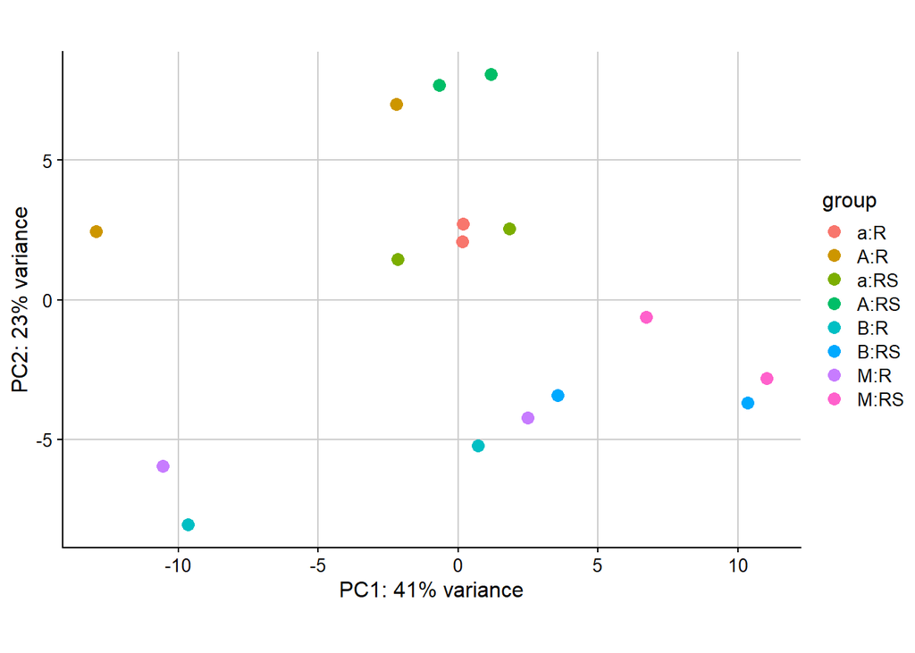

```r
plotPCA(rld_30m, intgroup = c("Strain", "Condition"))
```

## Plot PCA for 2h

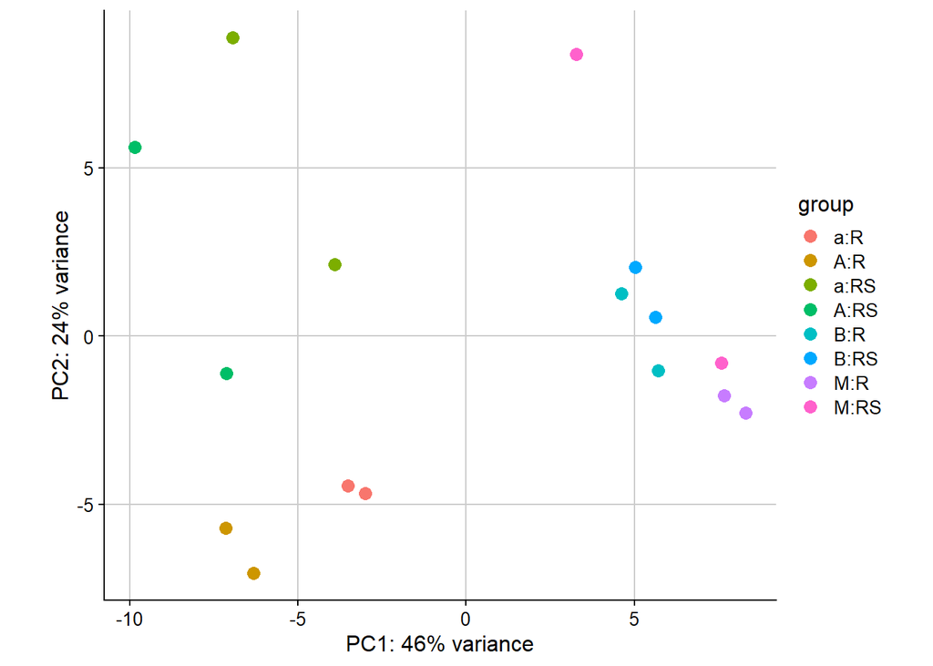

```r
plotPCA(rld_2h, intgroup = c("Strain", "Condition"))
```

## Plot PCA for 4h

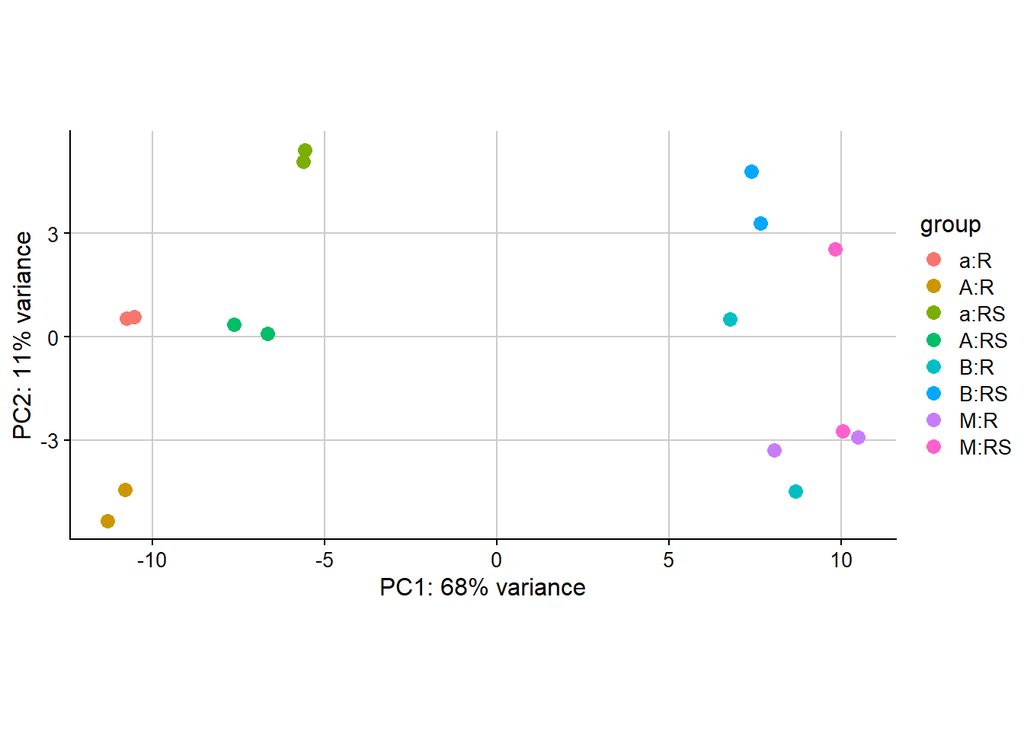

```r
plotPCA(rld_4h, intgroup = c("Strain", "Condition"))
```

# Differential gene expression testing

## dds0h

```r
dds0h <- DESeq(dds0h)
```

Calling results without any arguments will extract the estimated log2 fold changes and p values for the last variable in the design formula. If there are more than 2 levels for this variable, results will extract the results table for a comparison of the last level over the first level.

```r
(res0h <- results (dds0h))
```

```
## log2 fold change (MLE): Strain M vs a
## Wald test p-value: Strain M vs a
## DataFrame with 6795 rows and 6 columns
##             baseMean log2FoldChange     lfcSE      stat    pvalue      padj
##            <numeric>      <numeric> <numeric> <numeric> <numeric> <numeric>
## CNAG_00002   397.104      0.5238559  0.240541  2.177821 0.0294194  0.432060
## CNAG_00003   242.313      0.2863257  0.273619  1.046441 0.2953576  0.889829
## CNAG_00004   246.863     -0.0615071  0.258725 -0.237731 0.8120894  0.984234
## CNAG_00005   377.157     -0.1011692  0.294511 -0.343516 0.7312103  0.972655
## CNAG_00006   968.609     -0.0263341  0.262857 -0.100184 0.9201982  0.989102
## ...              ...            ...       ...       ...       ...       ...
## CNAG_08027   65.1114      -0.370657  0.360707 -1.027585  0.304145  0.890658
## CNAG_08028  171.8377       0.425347  0.281659  1.510152  0.131005  0.743083
## CNAG_08029   24.1179      -0.179085  0.533936 -0.335406  0.737319  0.972662
## CNAG_14001  146.0904       0.136189  0.289104  0.471072  0.637589  0.961714
## CNAG_14002   19.6777      -0.384791  0.587532 -0.654928  0.512514  0.947567
```

Use ‘relevel’ to change order of comparison dds0h$Strain <- relevel(dds0h$Strain, “A”)

As res is a DataFrame object, it carries metadata with information on the meaning of the columns

```r
mcols(res0h, use.names=TRUE)
```

```
## DataFrame with 6 rows and 2 columns
##                        type            description
##                 <character>            <character>
## baseMean       intermediate mean of normalized c..
## log2FoldChange      results log2 fold change (ML..
## lfcSE               results standard error: Stra..
## stat                results Wald statistic: Stra..
## pvalue              results Wald test p-value: S..
## padj                results   BH adjusted p-values
```

Summarise results.

```r
summary(res0h)
```

```
##
## out of 6769 with nonzero total read count
## adjusted p-value < 0.1
## LFC > 0 (up)       : 33, 0.49%
## LFC < 0 (down)     : 105, 1.6%
## outliers [1]       : 0, 0%
## low counts [2]     : 263, 3.9%
## (mean count < 9)
## [1] see 'cooksCutoff' argument of ?results
## [2] see 'independentFiltering' argument of ?results
```

There are two ways to be more strict about which set of genes are considered significant:

1. lower the false discovery rate threshold (the threshold on ‘padj’ in the results table)
2. Raise the log2 fold change threshold from 0 using the ‘lfcThreshold’ argument of results. See the DESeq2 vignette for a demonstration of the use of this argument. If we lower the false discovery rate threshold, we should also tell this value to results(), so that the function will use an alternative threshold for the optimal independent filtering step.

```r
res0h.05 <- results(dds0h, alpha=.05)
table(res0h.05$padj < .05)
```

```
##
## FALSE  TRUE
##  6658   111
```

How can I compare (a+A) against (B+M)?

## dds30m

```r
dds30m <- DESeq(dds30m)
        (res30m <- results (dds30m))
```

```
## log2 fold change (MLE): Strain M vs a
## Wald test p-value: Strain M vs a
## DataFrame with 6795 rows and 6 columns
##             baseMean log2FoldChange     lfcSE      stat     pvalue      padj
##            <numeric>      <numeric> <numeric> <numeric>  <numeric> <numeric>
## CNAG_00002  1701.767     -0.0920207 0.1113008 -0.826775 0.40836468 0.5945963
## CNAG_00003   104.735     -0.4565752 0.1591772 -2.868345 0.00412626 0.0240234
## CNAG_00004   278.047     -0.0207379 0.1288785 -0.160910 0.87216407 0.9255448
## CNAG_00005   522.930      0.3965436 0.1775616  2.233273 0.02553092 0.0897840
## CNAG_00006   574.585      0.2530693 0.0979154  2.584570 0.00975006 0.0453252
## ...              ...            ...       ...       ...        ...       ...
## CNAG_08027   82.1525     -0.1624667  0.184392 -0.881096 0.37826597 0.5616497
## CNAG_08028   41.8970     -0.0931390  0.241526 -0.385627 0.69977266 0.8200017
## CNAG_08029   30.4414     -0.6281298  0.298283 -2.105817 0.03522028 0.1136872
## CNAG_14001  645.5662     -0.0955128  0.102604 -0.930892 0.35190943 0.5363006
## CNAG_14002   76.1075     -0.5344766  0.197247 -2.709683 0.00673476 0.0341519
```

```r
        mcols(res30m, use.names=TRUE)
```

```
## DataFrame with 6 rows and 2 columns
##                        type            description
##                 <character>            <character>
## baseMean       intermediate mean of normalized c..
## log2FoldChange      results log2 fold change (ML..
## lfcSE               results standard error: Stra..
## stat                results Wald statistic: Stra..
## pvalue              results Wald test p-value: S..
## padj                results   BH adjusted p-values
```

```r
        summary(res30m)
```

```
##
## out of 6775 with nonzero total read count
## adjusted p-value < 0.1
## LFC > 0 (up)       : 1013, 15%
## LFC < 0 (down)     : 946, 14%
## outliers [1]       : 0, 0%
## low counts [2]     : 132, 1.9%
## (mean count < 3)
## [1] see 'cooksCutoff' argument of ?results
## [2] see 'independentFiltering' argument of ?results
```

## dds2h

```r
dds2h <- DESeq(dds2h)
        (res2h <- results (dds2h))
```

```
## log2 fold change (MLE): Strain M vs a
## Wald test p-value: Strain M vs a
## DataFrame with 6795 rows and 6 columns
##             baseMean log2FoldChange     lfcSE       stat      pvalue
##            <numeric>      <numeric> <numeric>  <numeric>   <numeric>
## CNAG_00002   508.183      0.0710689 0.1512892   0.469755 6.38530e-01
## CNAG_00003   134.779      0.0830572 0.1797045   0.462188 6.43947e-01
## CNAG_00004   223.929     -0.0789188 0.1596743  -0.494248 6.21131e-01
## CNAG_00005   781.495      0.8951805 0.1348375   6.638956 3.15913e-11
## CNAG_00006  1312.043      0.1101405 0.0937606   1.174699 2.40115e-01
## ...              ...            ...       ...        ...         ...
## CNAG_08027  265.7879     -0.2553184  0.155889 -1.6378170    0.101460
## CNAG_08028   93.8125     -0.2405134  0.205316 -1.1714307    0.241426
## CNAG_08029   92.7932      0.0141805  0.219850  0.0645008    0.948571
## CNAG_14001  331.1819      0.0822471  0.115879  0.7097673    0.477848
## CNAG_14002   48.6792      0.1033514  0.251502  0.4109366    0.681119
##                   padj
##              <numeric>
## CNAG_00002 8.41354e-01
## CNAG_00003 8.43080e-01
## CNAG_00004 8.33506e-01
## CNAG_00005 1.92792e-09
## CNAG_00006 5.35335e-01
## ...                ...
## CNAG_08027    0.340337
## CNAG_08028    0.537086
## CNAG_08029    0.977549
## CNAG_14001    0.741568
## CNAG_14002    0.861952
```

```r
        mcols(res2h, use.names=TRUE)
```

```
## DataFrame with 6 rows and 2 columns
##                        type            description
##                 <character>            <character>
## baseMean       intermediate mean of normalized c..
## log2FoldChange      results log2 fold change (ML..
## lfcSE               results standard error: Stra..
## stat                results Wald statistic: Stra..
## pvalue              results Wald test p-value: S..
## padj                results   BH adjusted p-values
```

```r
        summary(res2h)
```

```
##
## out of 6774 with nonzero total read count
## adjusted p-value < 0.1
## LFC > 0 (up)       : 465, 6.9%
## LFC < 0 (down)     : 546, 8.1%
## outliers [1]       : 0, 0%
## low counts [2]     : 0, 0%
## (mean count < 0)
## [1] see 'cooksCutoff' argument of ?results
## [2] see 'independentFiltering' argument of ?results
```

## dds4h

```r
dds4h <- DESeq(dds4h)
        (res4h <- results (dds4h))
```

```
## log2 fold change (MLE): Strain M vs a
## Wald test p-value: Strain M vs a
## DataFrame with 6795 rows and 6 columns
##             baseMean log2FoldChange     lfcSE      stat      pvalue        padj
##            <numeric>      <numeric> <numeric> <numeric>   <numeric>   <numeric>
## CNAG_00002  301.6972      0.3062967 0.1481590  2.067351 3.87011e-02 8.41718e-02
## CNAG_00003   95.2449     -0.3203126 0.1759023 -1.820969 6.86116e-02 1.32682e-01
## CNAG_00004  152.3694     -0.0749206 0.1321891 -0.566768 5.70872e-01 6.87567e-01
## CNAG_00005  344.5075      0.7708150 0.1338356  5.759416 8.44055e-09 1.50242e-07
## CNAG_00006 1595.4029      0.3429500 0.0901501  3.804213 1.42256e-04 7.89351e-04
## ...              ...            ...       ...       ...         ...         ...
## CNAG_08027  251.2148     -0.0290632  0.129517 -0.224397 0.822448697  0.88424241
## CNAG_08028   95.4776     -0.5073333  0.153615 -3.302625 0.000957846  0.00393613
## CNAG_08029   81.9898     -0.0482812  0.174096 -0.277324 0.781531050  0.85552290
## CNAG_14001  233.5212      0.0569784  0.130244  0.437473 0.661768432  0.76295937
## CNAG_14002   29.5084     -0.4823896  0.317466 -1.519500 0.128636789  0.21927904
```

```r
        mcols(res4h, use.names=TRUE)
```

```
## DataFrame with 6 rows and 2 columns
##                        type            description
##                 <character>            <character>
## baseMean       intermediate mean of normalized c..
## log2FoldChange      results log2 fold change (ML..
## lfcSE               results standard error: Stra..
## stat                results Wald statistic: Stra..
## pvalue              results Wald test p-value: S..
## padj                results   BH adjusted p-values
```

```r
        summary(res4h)
```

```
##
## out of 6764 with nonzero total read count
## adjusted p-value < 0.1
## LFC > 0 (up)       : 1636, 24%
## LFC < 0 (down)     : 1620, 24%
## outliers [1]       : 0, 0%
## low counts [2]     : 0, 0%
## (mean count < 0)
## [1] see 'cooksCutoff' argument of ?results
## [2] see 'independentFiltering' argument of ?results
```

```r
res4h.05 <- results(dds4h, alpha=.05)
            summary(res4h.05)
```

```
##
## out of 6764 with nonzero total read count
## adjusted p-value < 0.05
## LFC > 0 (up)       : 1373, 20%
## LFC < 0 (down)     : 1366, 20%
## outliers [1]       : 0, 0%
## low counts [2]     : 0, 0%
## (mean count < 0)
## [1] see 'cooksCutoff' argument of ?results
## [2] see 'independentFiltering' argument of ?results
```

```r
            table(res4h.05$padj < .05)
```

```
##
## FALSE  TRUE
##  4025  2739
```

```r
            summary(res4h.05)
```

```
##
## out of 6764 with nonzero total read count
## adjusted p-value < 0.05
## LFC > 0 (up)       : 1373, 20%
## LFC < 0 (down)     : 1366, 20%
## outliers [1]       : 0, 0%
## low counts [2]     : 0, 0%
## (mean count < 0)
## [1] see 'cooksCutoff' argument of ?results
## [2] see 'independentFiltering' argument of ?results
```

In general, the results for a comparison of any two levels of a variable can be extracted using the contrast argument to results. The user should specify three values: the name of the variable, the name of the level in the numerator, and the name of the level in the denominator. Here we extract results for the log2 of the fold change of one cell line over another:

```r
( res.GAT201 <- results(dds4h, contrast=c("Strain", "A", "M")) )
```

```
## log2 fold change (MLE): Strain A vs M
## Wald test p-value: Strain A vs M
## DataFrame with 6795 rows and 6 columns
##             baseMean log2FoldChange     lfcSE        stat      pvalue
##            <numeric>      <numeric> <numeric>   <numeric>   <numeric>
## CNAG_00002  301.6972      -0.421557 0.1472506    -2.86286 4.19842e-03
## CNAG_00003   95.2449       0.407003 0.1717395     2.36988 1.77937e-02
## CNAG_00004  152.3694       0.138972 0.1286025     1.08063 2.79861e-01
## CNAG_00005  344.5075      -0.514547 0.1306096    -3.93958 8.16236e-05
## CNAG_00006 1595.4029      -0.195895 0.0894239    -2.19063 2.84783e-02
## ...              ...            ...       ...         ...         ...
## CNAG_08027  251.2148     -0.0562455  0.128287  -0.4384347 6.61071e-01
## CNAG_08028   95.4776      0.6322244  0.148548   4.2560204 2.08098e-05
## CNAG_08029   81.9898     -0.0128484  0.170860  -0.0751982 9.40057e-01
## CNAG_14001  233.5212     -6.0234292  0.370823 -16.2434118 2.48699e-59
## CNAG_14002   29.5084      0.3646918  0.314304   1.1603152 2.45920e-01
##                   padj
##              <numeric>
## CNAG_00002 0.017464998
## CNAG_00003 0.054239119
## CNAG_00004 0.431300653
## CNAG_00005 0.000679093
## CNAG_00006 0.078399480
## ...                ...
## CNAG_08027 7.79140e-01
## CNAG_08028 2.14897e-04
## CNAG_08029 9.63124e-01
## CNAG_14001 5.25688e-57
## CNAG_14002 3.93799e-01
```

```r
                summary(res.GAT201)
```

```
##
## out of 6764 with nonzero total read count
## adjusted p-value < 0.1
## LFC > 0 (up)       : 1292, 19%
## LFC < 0 (down)     : 1359, 20%
## outliers [1]       : 0, 0%
## low counts [2]     : 0, 0%
## (mean count < 0)
## [1] see 'cooksCutoff' argument of ?results
## [2] see 'independentFiltering' argument of ?results
```

# Plotting counts for individual genes

A quick way to visualize the counts for a particular gene is to use the ’plotCount’s function, which takes as arguments the DESeqDataSet, a gene name, and the group over which to plot the counts.

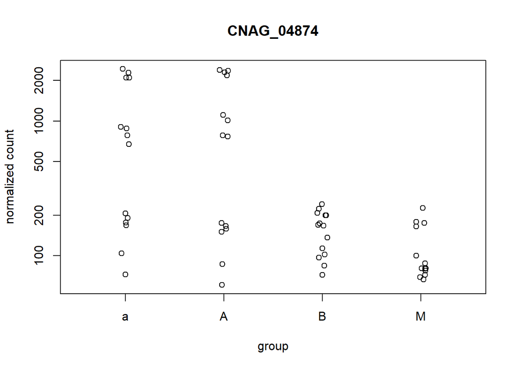

```r
topGene <- rownames(res4h.05)[which.min(res4h.05$padj)]
plotCounts(dds, gene=topGene, intgroup=c("Strain"))
```

Use ggplot2 to plot counts

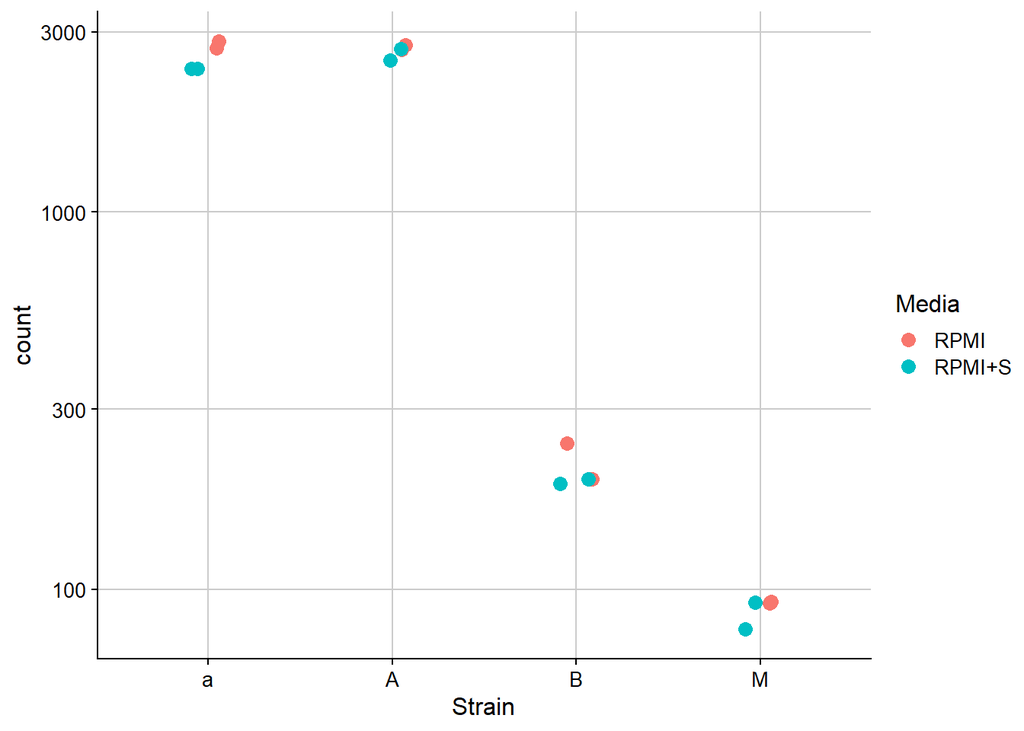

```r
data <- plotCounts(dds4h, gene=topGene, intgroup=c("Strain","Media","BioRep"), returnData=TRUE)
ggplot(data, aes(x=Strain, y=count, color=Media)) +
  scale_y_log10() +
  geom_point(position=position_jitter(width=.1,height=0), size=3)
```

Here we use a more structural arrangement instead of random jitter, and color by the Media.

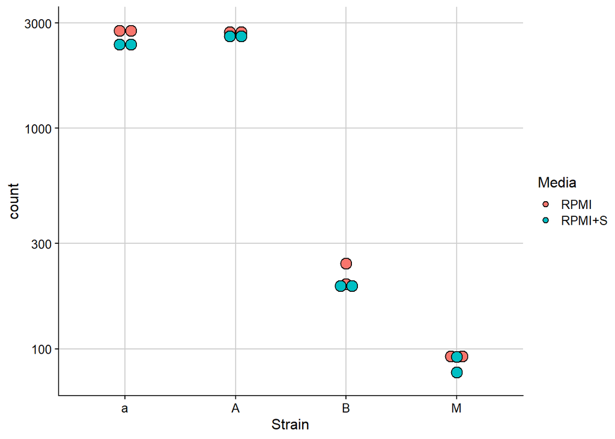

```r
ggplot(data, aes(x=Strain, y=count, fill=Media)) +
  scale_y_log10() +
  geom_dotplot(binaxis="y", stackdir="center")
```

# MA Plot Fold Change

An ‘MA-plot’ provides a useful overview for an experiment with a two-group comparison. The log2 fold change for a particular comparison is plotted on the y-axis and the average of the counts normalized by size factor is shown on the x-axis

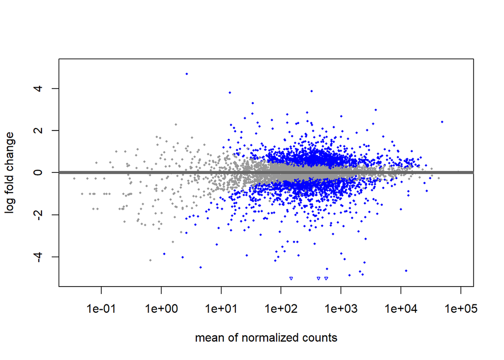

```r
plotMA(res4h.05, ylim=c(-5,5))
```

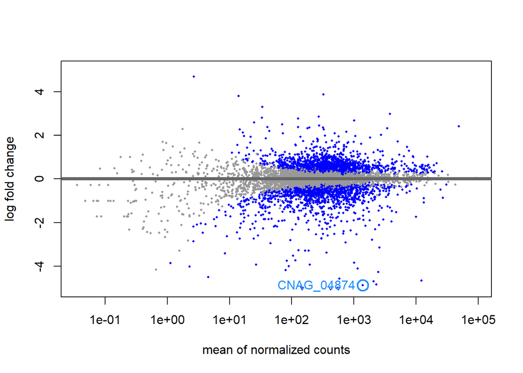

```r
plotMA(res4h.05, ylim=c(-5,5))
with(res4h.05[topGene, ], {
  points(baseMean, log2FoldChange, col="dodgerblue", cex=2, lwd=2)
  text(baseMean, log2FoldChange, topGene, pos=2, col="dodgerblue")
})
```

# Gene Clustering

Load ‘genefilter’

```r
library("genefilter")
```

## rld_4h Top 50

```r
topVarGenes50 <- head(order(-rowVars(assay(rld_4h))),50)
print(topVarGenes50)
```

```
##  [1] 5650 3436 1749 4321 1276 6022 5608  384 1359 6002 5519 6110 6018 6284 6153
## [16] 6150 6165 4702 6281 3107 3210 1370  153 6686  633 1983 5212 6021 4567 6024
## [31] 6023 6017 5018  839 4622 6794 4190 5609 2520 3553 5257  510 5518 4565 4553
## [46] 1115 2346 3394 4324 1878
```

```r
write.csv(topVarGenes50, file = "~/Documents/GitHub/CryptoGat201RNASeq_draft/results_deseq/rld_4h_top50.csv")
```

## rld_4h Top 100

```r
topVarGenes100 <- head(order(-rowVars(assay(rld_4h))),100)
print(topVarGenes100)
```

```
##   [1] 5650 3436 1749 4321 1276 6022 5608  384 1359 6002 5519 6110 6018 6284 6153
##  [16] 6150 6165 4702 6281 3107 3210 1370  153 6686  633 1983 5212 6021 4567 6024
##  [31] 6023 6017 5018  839 4622 6794 4190 5609 2520 3553 5257  510 5518 4565 4553
##  [46] 1115 2346 3394 4324 1878  246 2843  576 5759 5209 5481 6280 6020  662 4655
##  [61] 3624 1347  770 4316  501 2645 2587 6019 4348 3804 4703 1118 5470 1752 5780
##  [76]  458 2934  540 6658 4118 1484 2433 5560  782 2058 1486 3039 4210 1332  196
##  [91]  914 2409 1588 1772 1533  647 3297 6655  556 6444
```

```r
write.csv(topVarGenes100, file = "~/Documents/GitHub/CryptoGat201RNASeq_draft/results_deseq/rld_4h_top100.csv")
```

# Gene clustering Heatmap

The heatmap becomes more interesting if we do not look at absolute expression strength but rather at the amount by which each gene deviates in a specific sample from the gene’s average across all samples. Hence, we center each genes’ values across samples, and plot a heatmap.

## rld_4h Top 50

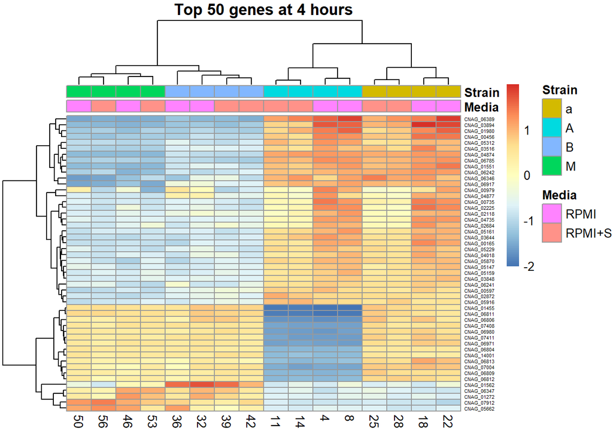

```r
mat4h <- assay(rld_4h)[ topVarGenes50, ]
mat4h <- mat4h - rowMeans(mat4h)
df <- as.data.frame(colData(rld_4h)[,c("Media","Strain")])
pheatmap(mat4h, main = "Top 50 genes at 4 hours", annotation_col=df, fontsize =10, fontsize_row = 4)
```

```r
write.csv(mat4h, file = "~/Documents/GitHub/CryptoGat201RNASeq_draft/results_deseq/mat4h_top50.csv")
```

## rld_4h Top 100

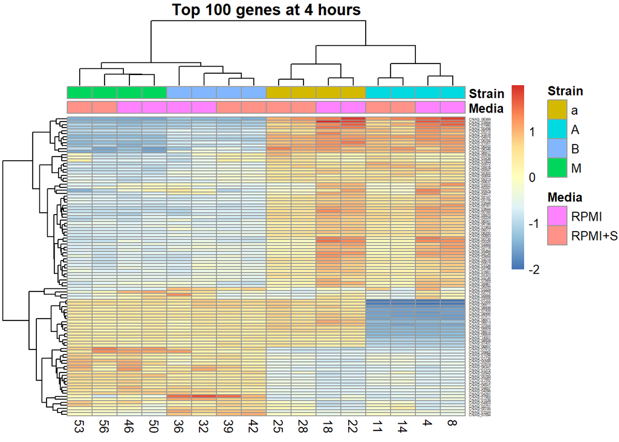

```r
mat4h <- assay(rld_4h)[ topVarGenes100, ]
mat4h <- mat4h - rowMeans(mat4h)
df <- as.data.frame(colData(rld_4h)[,c("Media","Strain")])
pheatmap(mat4h, main = "Top 100 genes at 4 hours", annotation_col=df, fontsize =10, fontsize_row = 3)
```

```r
write.csv(mat4h, file = "~/Documents/GitHub/CryptoGat201RNASeq_draft/results_deseq/mat4h_top100.csv")
```

```r
topVarGenes250_0h <- head(order(-rowVars(assay(rld_0h))),250)
print(topVarGenes250_0h)
```

```
##   [1] 1276 6153 6150 6018 1403 6284 6022 6019 6281 1572 1368 6165  839 6794 1379
##  [16] 6023 2353 6017 2363 6020 6589 6716 4020 3275 1359 6356 1274 6282 1983 6437
##  [31] 3150 1329 6026 4731 4963 4139 5730 6141  322 1497 1412 4649 6234 1330 6024
##  [46] 1957 6027 2606 6548 1118 6166 5564 5806  134 6444 3558 1984 6021 1277 1709
##  [61] 6083 6235 1377 5271 2645 3312 4410 4257 1386 6585 5885 1334 1434 1766 3868
##  [76] 5146 5281 4010 6212 3396 1152 6312 4550 3688  338 5649 2227 5450  349 1405
##  [91] 5097 4693  722 1859 2837 3034 3893 6572 3116 2554 1125 2860 1591 4702 5489
## [106] 5675 1134  581 3102 1795 1587  259 4791 5082 4788 6047 5062 1775 2532 6630
## [121] 3190  653 2533 2212  549  672   23  662 6341 2433 2089  296  545 5401 2823
## [136] 4050 1101 4392 1271 5697 5399 5598 2241 4313 5315 3315 5609 1408 6291 1237
## [151]  892  210 2267 3391 6588 5398 2407 4627  599 5407 1915 5538 4942 4626 4216
## [166] 1832 4458 3953 6016 6586 1331 5852 1418 6034 5733 5103 1952 1667 1360 4264
## [181] 3193  782 5651 3530 2712 2246 4866 3006 1026 1406 6616 1458 3237 3733 4304
## [196]  777 4314 4998 1897 2336 3096  812 1372 5542 3287 5488 1738 1338 6725  626
## [211] 4040 5940 2499 5052 1332 1393 1402 4090 3342 1280 1598 3976 1115 4703 5323
## [226]  696 1787 1682 2058 2073 6557 4118 6095 6412 4699 5078 4911  621 4937 4430
## [241]  746 3447 3329 4594 6421 5711 4421 3240 3820 3983
```

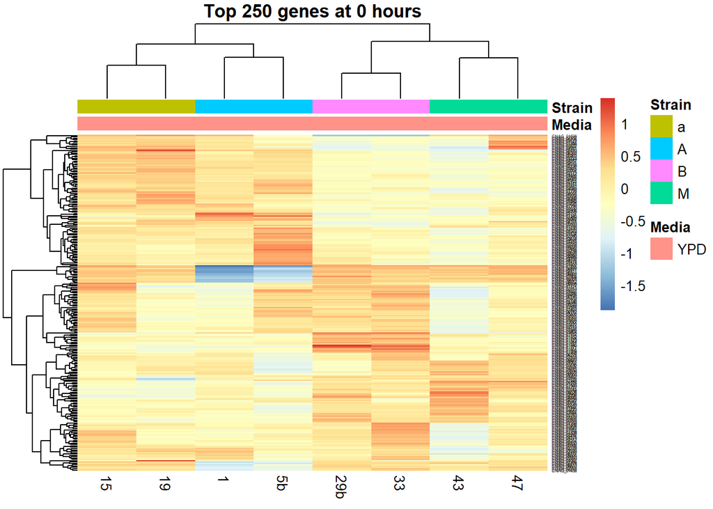

```r
write.csv(topVarGenes100, file = "~/Documents/GitHub/CryptoGat201RNASeq_draft/results_deseq/rld_0h_top250.csv")

mat0h <- assay(rld_0h)[ topVarGenes250_0h, ]
mat0h <- mat0h - rowMeans(mat0h)
df <- as.data.frame(colData(rld_0h)[,c("Media","Strain")])
pheatmap(mat0h, main = "Top 250 genes at 0 hours", annotation_col=df, fontsize =10, fontsize_row = 3)
```

```r
write.csv(mat0h, file = "~/Documents/GitHub/CryptoGat201RNASeq_draft/results_deseq/mat0h_top250.csv")
```

```r
topVarGenes250_30m <- head(order(-rowVars(assay(rld_30m))),250)
print(topVarGenes250_30m)
```

```
##   [1] 1276 6022 1359  653 3181 2645 6794 6153 6019 6150 6021 1667 6018 6020 6284
##  [16] 6023 3104 6165 1437  814 1222 6281 6016 2073 1765 6787 1368 6774 2391 6009
##  [31] 5436  349  265 6017 3820 2532 1833 1329  891 5583 5697 3775 6024 3629 1379
##  [46] 5547 5313 4693 3302 6025 6280 2171 4012 4410  324 6421 1426 4541 5609 3150
##  [61] 4731 6753 2657 1332 2246 5722 3561 2843 4257 2192  328 1572 5884 6008 2655
##  [76] 5542 4649 1407  390  458  354  134 1046 5292  501 4963 6548 1414 2794 3797
##  [91] 4392 1366 4841 3894 1777 3733  459 2207 3381  974 1408 5951  119 4626 1208
## [106] 5209 4881 3232 3630 3062 1928 5472 5539 4164 6282 5733 5109  121 1594 1370
## [121] 1965  338 5428 5389 1277 3391 3529 2024 4313 6725   66 3063 2278 6444 5649
## [136]  940 1848  599 5450  885 2477 5391 1347 6640 6141  422 6170 3275 3006 6589
## [151] 2087 1380 6413  787 4020 5885 6130 6464 4304 5072 6716 4593 5018 4217 1859
## [166] 2473 2953 5563 6249 5852 5886 3205 3108 2996 4104 6027  246 4957 6312 3747
## [181] 1860 6452 4050 6145 1831 3107 4689 3518 2212 1330 4929 5437 2163 5538 2178
## [196] 5772 5244 2326 1118 3858  762 2407 3115 6082 1424   36 3016  370 1345 3692
## [211] 6283 3447 4246  378 1418 4692  844 1280 5848 4403 6561 5564 1466 4339 1328
## [226] 4475 1470 3416 3970  662 6645 3814  456 6166  992 1863 3852  769 5009 1549
## [241] 1170 4090 5738 4682   73 1583 3838  270 1672  313
```

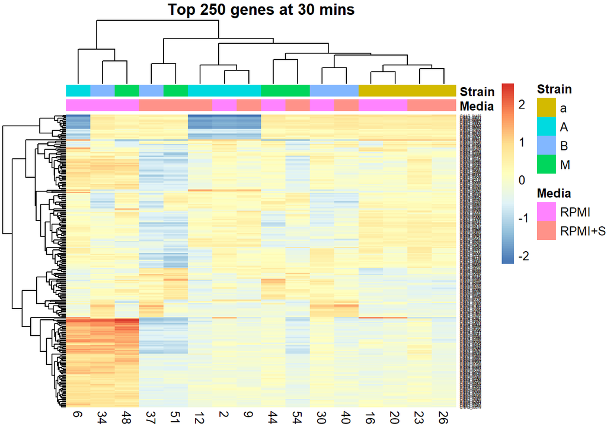

```r
write.csv(topVarGenes250_30m, file = "~/Documents/GitHub/CryptoGat201RNASeq_draft/results_deseq/rld_30m_top250.csv")

mat30m <- assay(rld_30m)[ topVarGenes250_30m, ]
mat30m <- mat30m - rowMeans(mat30m)
df <- as.data.frame(colData(rld_30m)[,c("Media","Strain")])
pheatmap(mat30m, main = "Top 250 genes at 30 mins", annotation_col=df, fontsize =10, fontsize_row = 3)
```

```r
write.csv(mat30m, file = "~/Documents/GitHub/CryptoGat201RNASeq_draft/results_deseq/mat30m_top250.csv")
```

```r
topVarGenes250_2h <- head(order(-rowVars(assay(rld_2h))),250)
print(topVarGenes250_2h)
```

```
##   [1] 1276 1359 6022 5519 6153 6284 6018 6150 6165 6281 4321  384 6021 6110 6794
##  [16] 6023 2391 4324 6002 6019 5257 5182 3820 1222 6686 6024 5650 2645  265 3002
##  [31] 3107  501 6017 6020 5547 5609 5518 1667 1709 6774 6787 6280 2843 2737 4693
##  [46] 5212 5308  653  814 4622 4702 3181 1749  349 4008 5951 4963 1370 6009 3104
##  [61] 1347  576 2073  246  782 4731 6750 5481 4703 5697 1928 5980 4841 4012  839
##  [76]  390  770 4772 4989 5850 1772 1437 6655 4649 3150 1752 1332 6282 1965 5436
##  [91] 5256 5470 2765 1475  662 5583  556 4950  818 3391  114 6025  510 1372 1368
## [106]  891 2570 5780 2433 5608 2058 5018  914 3394  974 5820 1765  310 1572 2206
## [121] 6648 5924 5292 2087 6753 4210 6166 1280 3775 3289 4087 3733 5884  494 5309
## [136] 4089  633 5689 5811 3662 2520  134 1407 6314 5542 3275 4489 5255  540 1341
## [151]   98 4654 2085 2171 2246 6548 1458 3804 2692 2953 3236  338 6444 5450  313
## [166] 1046  459 1737 5281 3927 3702 6016 5722 4190 6585 5976  480 1329 3210   68
## [181] 4313 4133  741 6715 1594 2657 4118 2188 6658 1125 3436 4286 1277 4212 2229
## [196] 2207 6275  330 1567  213 2934 2212 3381 3039 1190 5209 2033 2587 6716 5539
## [211] 5254  992 6279 3019 2488 5340 5082 4258 6645 1105 5738 5885 2877 4538 2191
## [226] 1373  815 1408 5755 6355 3062 3858 3558 5756 2470 6014 1521 1018 3822 5759
## [241] 3006 6008 2009  421  392 3267 4396 6034 6116 6222
```

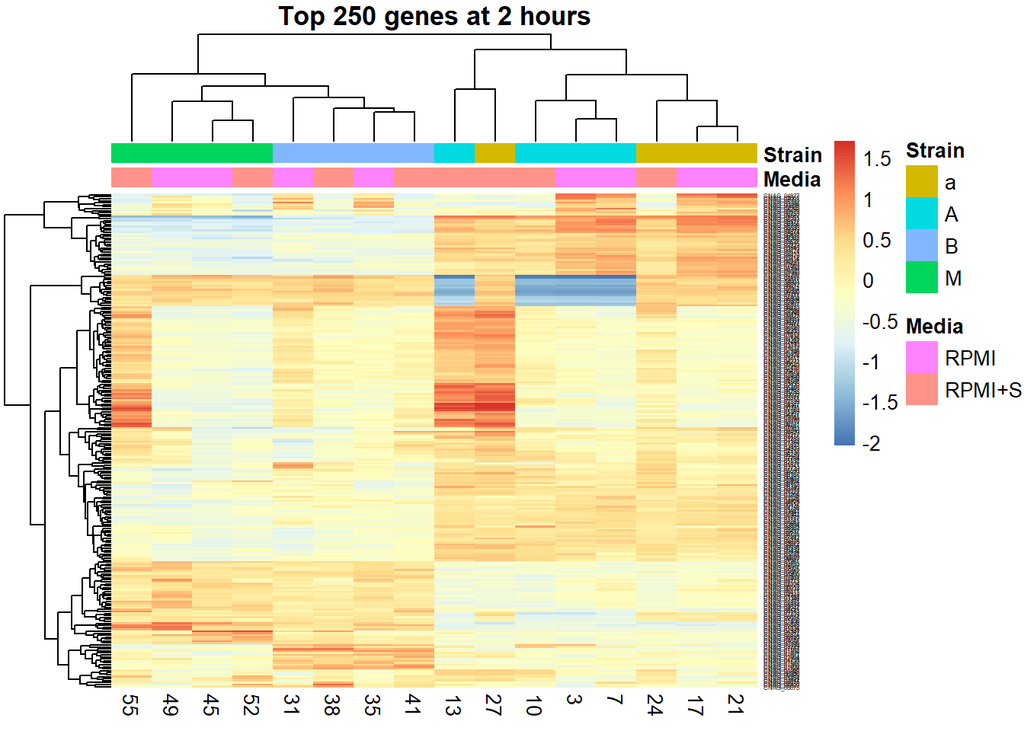

```r
write.csv(topVarGenes250_2h, file = "~/Documents/GitHub/CryptoGat201RNASeq_draft/results_deseq/rld_2h_top250.csv")

mat2h <- assay(rld_2h)[ topVarGenes250_2h, ]
mat2h <- mat2h - rowMeans(mat2h)
df <- as.data.frame(colData(rld_2h)[,c("Media","Strain")])
pheatmap(mat2h, main = "Top 250 genes at 2 hours", annotation_col=df, fontsize =10, fontsize_row = 3)
```

```r
write.csv(mat2h, file = "~/Documents/GitHub/CryptoGat201RNASeq_draft/results_deseq/mat2h_top250.csv")
```

```r
topVarGenes250_4h <- head(order(-rowVars(assay(rld_4h))),250)
print(topVarGenes250_4h)
```

```
##   [1] 5650 3436 1749 4321 1276 6022 5608  384 1359 6002 5519 6110 6018 6284 6153
##  [16] 6150 6165 4702 6281 3107 3210 1370  153 6686  633 1983 5212 6021 4567 6024
##  [31] 6023 6017 5018  839 4622 6794 4190 5609 2520 3553 5257  510 5518 4565 4553
##  [46] 1115 2346 3394 4324 1878  246 2843  576 5759 5209 5481 6280 6020  662 4655
##  [61] 3624 1347  770 4316  501 2645 2587 6019 4348 3804 4703 1118 5470 1752 5780
##  [76]  458 2934  540 6658 4118 1484 2433 5560  782 2058 1486 3039 4210 1332  196
##  [91]  914 2409 1588 1772 1533  647 3297 6655  556 6444 3603 4693 3662 3820 5980
## [106] 4989  330  331 3236 2737 6222 6282 4191 5855 4833 4564 5792 1125 5850 4481
## [121]  590 4396 1372 2622 6774 4824  114 4649 6558 5657 2928 3002 1764 6312 5182
## [136] 5183 4776 4998 4594 1393 5885 1392 3281 1222 2033 1342 2708 6567 5437 3088
## [151] 4656 5082 3375  259 5697  757  818  986 6098 6145 5036  274 6355 4008 6166
## [166] 4491 1412 2287 2176 3147 5330 4313 4451 1280 5456 5884  511  324   85 3275
## [181] 4654 2570 4089 4643 2470 5924 4902 6025 1408 2391  213  802 6619  993 4286
## [196] 2741 6314 1475 1880 2417 4731 1581 6522 2794 3604 3152  265 5542 6604 3335
## [211] 3631  741 4095  494 6517 2512 1318  722 6787 5180 5660 6046  349 5683 3150
## [226] 4087 3289 4199 3899 1775 5820 3835 3017 3858 1426 4560  224  328 5159 1667
## [241] 1368 5216 6703  769 1567 6236 2191 3796 5278 1411
```

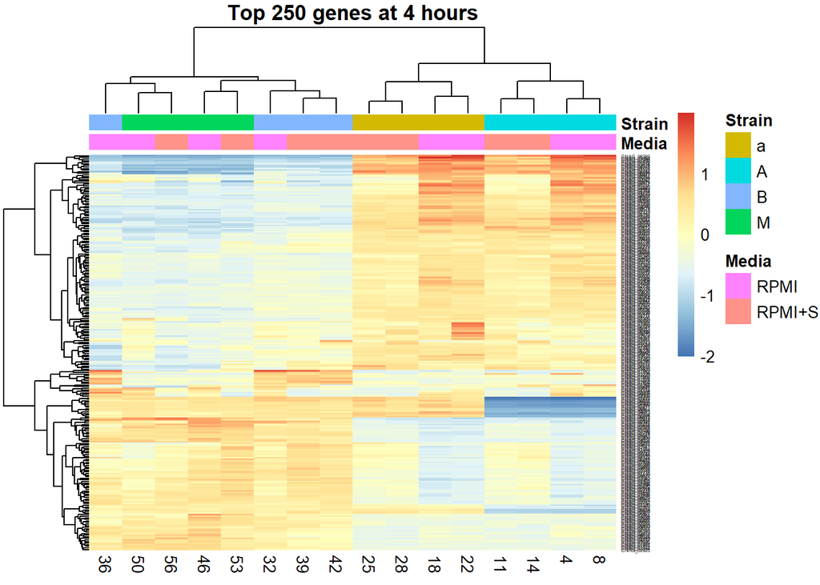

```r
write.csv(topVarGenes250_4h, file = "~/Documents/GitHub/CryptoGat201RNASeq_draft/results_deseq/rld_4h_top250.csv")

mat4h <- assay(rld_4h)[ topVarGenes250_4h, ]
mat4h <- mat4h - rowMeans(mat4h)
df <- as.data.frame(colData(rld_4h)[,c("Media","Strain")])
pheatmap(mat4h, main = "Top 250 genes at 4 hours", annotation_col=df, fontsize =10, fontsize_row = 3)
```

```r
write.csv(mat4h, file = "~/Documents/GitHub/CryptoGat201RNASeq_draft/results_deseq/mat4h_top250.csv")
```

```r
topVarGenes1000_30m <- head(order(-rowVars(assay(rld_30m))),1000)
head(topVarGenes1000_30m)
```

```
## [1] 1276 6022 1359  653 3181 2645
```

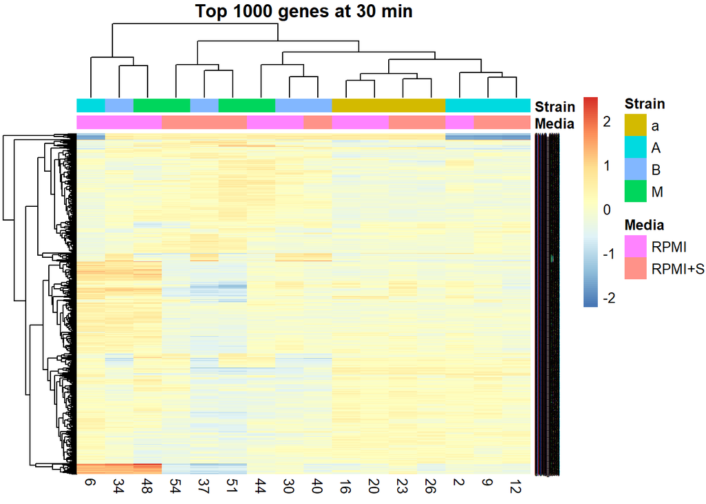

```r
write.csv(topVarGenes1000_30m, file = "~/Documents/GitHub/CryptoGat201RNASeq_draft/results_deseq/rld_30m_top1000.csv")

mat30m <- assay(rld_30m)[ topVarGenes1000_30m, ]
mat30m <- mat30m - rowMeans(mat30m)
df <- as.data.frame(colData(rld_30m)[,c("Media","Strain")])
pheatmap(mat30m, main = "Top 1000 genes at 30 min", annotation_col=df, fontsize =10, fontsize_row = 3)
```

```r
write.csv(mat30m, file = "~/Documents/GitHub/CryptoGat201RNASeq_draft/results_deseq/mat30m_top1000.csv")
```

```r
topVarGenes1000_2h <- head(order(-rowVars(assay(rld_2h))),1000)
head(topVarGenes1000_2h)
```

```
## [1] 1276 1359 6022 5519 6153 6284
```

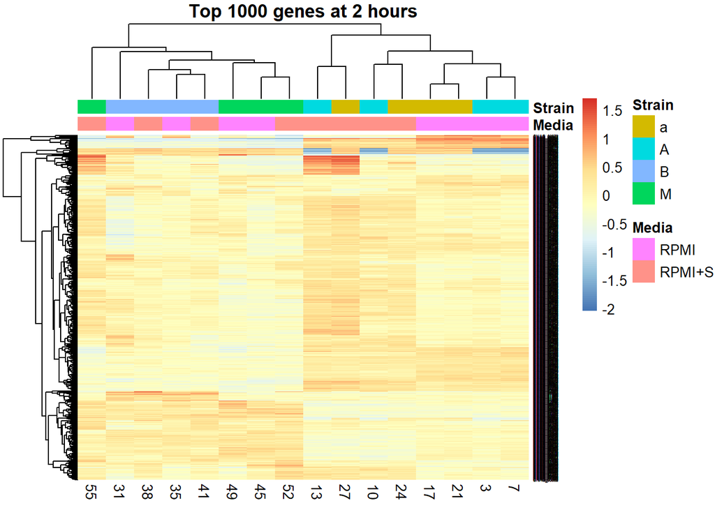

```r
write.csv(topVarGenes1000_2h, file = "~/Documents/GitHub/CryptoGat201RNASeq_draft/results_deseq/rld_2h_top1000.csv")

mat2h <- assay(rld_2h)[ topVarGenes1000_2h, ]
mat2h <- mat2h - rowMeans(mat2h)
df <- as.data.frame(colData(rld_2h)[,c("Media","Strain")])
pheatmap(mat2h, main = "Top 1000 genes at 2 hours", annotation_col=df, fontsize =10, fontsize_row = 3)
```

```r
write.csv(mat2h, file = "~/Documents/GitHub/CryptoGat201RNASeq_draft/results_deseq/mat2h_top1000.csv")
```

```r
topVarGenes1000_4h <- head(order(-rowVars(assay(rld_4h))),1000)
head(topVarGenes1000_4h)
```

```
## [1] 5650 3436 1749 4321 1276 6022
```

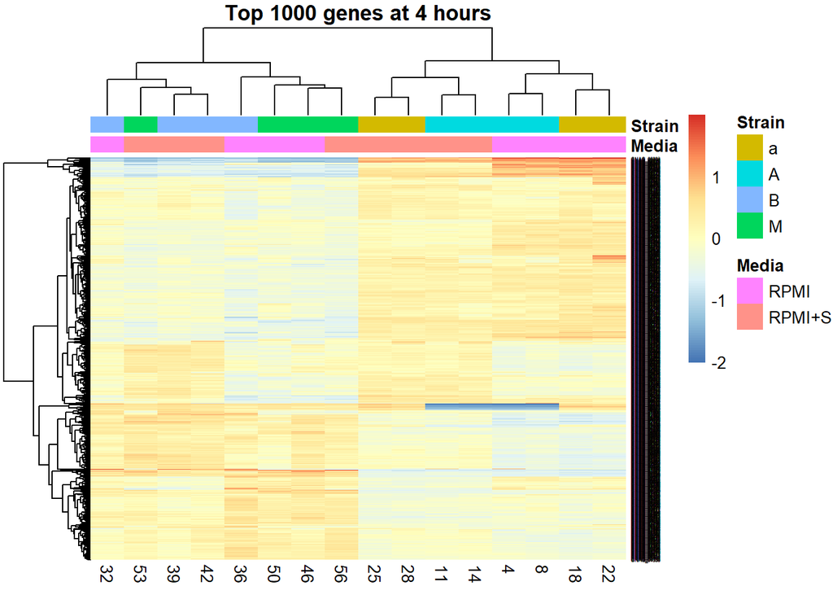

```r
write.csv(topVarGenes1000_4h, file = "~/Documents/GitHub/CryptoGat201RNASeq_draft/results_deseq/rld_4h_top1000.csv")

mat4h <- assay(rld_4h)[ topVarGenes1000_4h, ]
mat4h <- mat4h - rowMeans(mat4h)
df <- as.data.frame(colData(rld_4h)[,c("Media","Strain")])
pheatmap(mat4h, main = "Top 1000 genes at 4 hours", annotation_col=df, fontsize =10, fontsize_row = 3)
```

```r
write.csv(mat4h, file = "~/Documents/GitHub/CryptoGat201RNASeq_draft/results_deseq/mat4h_top1000.csv")
```

# Calculate DESeq2 fold-change and p-values

Take ‘samplesheet_4h’ and ‘counts_4h’ and put into DESeq2.

The tilda sign (above #) expresses a formula in R e.g. compare whats happening in time and condition.

```r
dds_4h <- DESeqDataSetFromMatrix(countData = counts_4h,
                              colData = samplesheet_4h,
                              design = ~ GAT201) %>%
           DESeq()
```

# Results from DESeq

Intercept = mean gene expression.

Condition y v capsule = results you want Gat201 No v Yes, therefore induced genes are induced in WT and repressed genes are repressed in Wt and so induced in Gat201?

```r
 res_dds4h <- results(dds_4h)
 head(res_dds4h)
```

```
## log2 fold change (MLE): GAT201 No vs Yes
## Wald test p-value: GAT201 No vs Yes
## DataFrame with 6 rows and 6 columns
##             baseMean log2FoldChange     lfcSE      stat      pvalue        padj
##            <numeric>      <numeric> <numeric> <numeric>   <numeric>   <numeric>
## CNAG_00002  301.6972      0.3094943 0.1093916  2.829233 4.66598e-03 1.39095e-02
## CNAG_00003   95.2449     -0.4553357 0.1284694 -3.544314 3.93637e-04 1.72781e-03
## CNAG_00004  152.3694     -0.0890044 0.0954636 -0.932339 3.51162e-01 4.77274e-01
## CNAG_00005  344.5075      0.5629809 0.1021952  5.508878 3.61129e-08 4.79897e-07
## CNAG_00006 1595.4029      0.3088727 0.0699205  4.417483 9.98570e-06 7.18545e-05
## CNAG_00007  433.3385      0.3775899 0.1029696  3.667004 2.45409e-04 1.16324e-03
```

```r
 sum(res_dds4h$padj <0.05, na.rm = T)
```

```
## [1] 2898
```

2898 genes have an adjusted p-value less than 0.05 when comparing Gat201 No vs Yes.

# Plot MA

Pick out what we want.

This plot method is built in, you have more control in ggplot2.

Plot base mean RNA abundance of normalised counts on x axis, log2fold change on y axis.

Significant genes are in blue, to do with p value and false discovery rate.

Show up and down regulated above and below line of x axis.

You will get:

1. base mean
2. log2fold change (how much the diff is)
3. logfold change std error
4. stat = test statistic
5. pvalue (how likely diff is actually diff)
6. adjusted p value (how likely diff is actually diff)

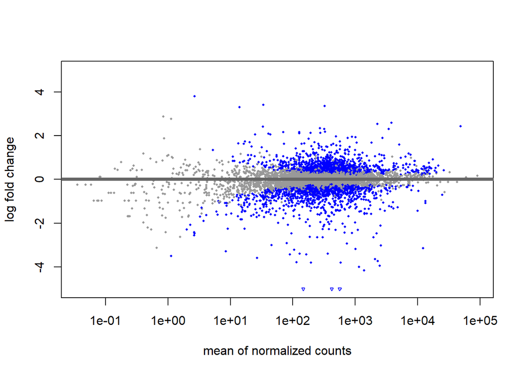

```r
MA_4h <- results(dds_4h,lfcThreshold = 0.05, alpha = 0.05)
plotMA(MA_4h, ylim=c(-5,5))
```

```r
print(plotMA)
```

[output not shown]

```r
summary(MA_4h)
```

```
##
## out of 6764 with nonzero total read count
## adjusted p-value < 0.05
## LFC > 0.05 (up)    : 1178, 17%
## LFC < -0.05 (down) : 1142, 17%
## outliers [1]       : 0, 0%
## low counts [2]     : 0, 0%
## (mean count < 0)
## [1] see 'cooksCutoff' argument of ?results
## [2] see 'independentFiltering' argument of ?results
```

# Significant Genes

Use the same values for our cutoff to determine which genes we want to consider as significantly differentially expressed. The ‘resSigind’ variable will contain genes that are induced and ‘resSigrep’ will contain genes that are repressed when comparing WT with Gat201 deletion mutants. To create one dataframe of differentially expressed genes, combine the two dataframe’s. Use the ‘rbind’ command because the columns are the same in both sets. Use ‘rownames’ to see the names of the differentially expressed genes.

## Significant genes at 0 hours

```r
dds_0h <- DESeqDataSetFromMatrix(countData = counts_0h,
                              colData = samplesheet_0h,
                              design = ~ GAT201) %>%
           DESeq()
res_dds0h <- results(dds_0h)
             head(res_dds0h)
```

```
## log2 fold change (MLE): GAT201 No vs Yes
## Wald test p-value: GAT201 No vs Yes
## DataFrame with 6 rows and 6 columns
##             baseMean log2FoldChange     lfcSE      stat      pvalue        padj
##            <numeric>      <numeric> <numeric> <numeric>   <numeric>   <numeric>
## CNAG_00002   397.104      0.7677538  0.166176  4.620113 3.83530e-06 0.000396668
## CNAG_00003   242.313      0.1006192  0.185537  0.542314 5.87602e-01 0.831978459
## CNAG_00004   246.863     -0.2291649  0.165200 -1.387198 1.65381e-01 0.494058151
## CNAG_00005   377.157     -0.0567369  0.201094 -0.282141 7.77836e-01 0.915518254
## CNAG_00006   968.609      0.0392003  0.174663  0.224434 8.22419e-01 0.935186022
## CNAG_00007   101.799     -0.2146957  0.190068 -1.129574 2.58656e-01 0.599610089
```

```r
             sum(res_dds0h$padj <0.05, na.rm = T)
```

```
## [1] 349
```

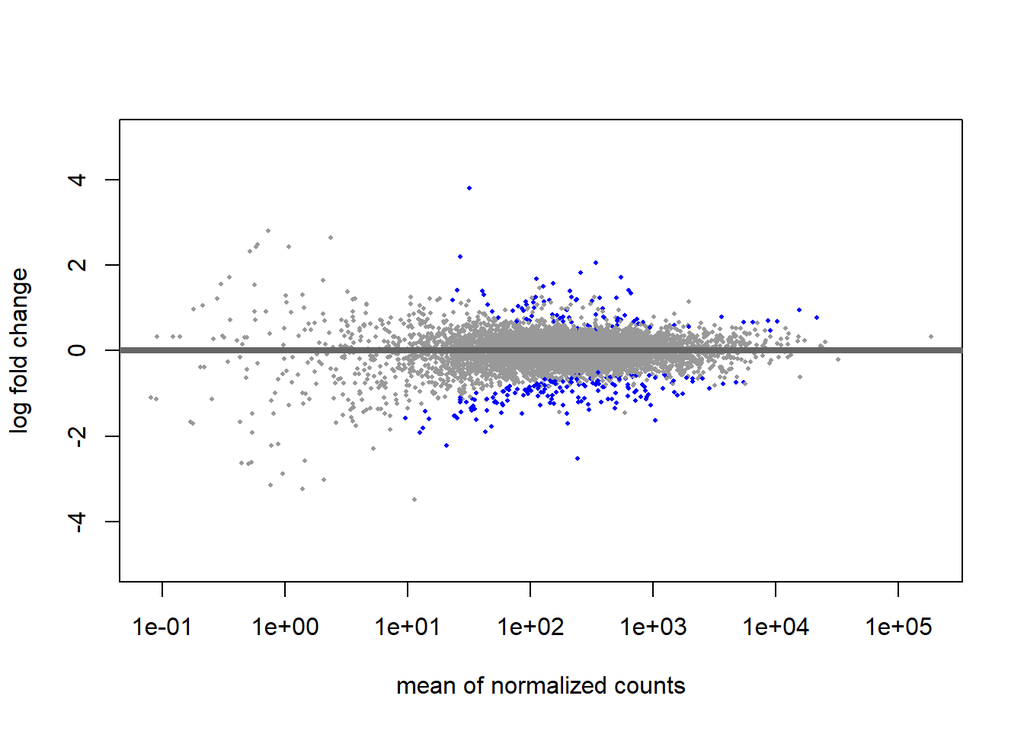

```r
MA_0h <- results(dds_0h,lfcThreshold = 0.05, alpha = 0.05)
         plotMA(MA_0h, ylim=c(-5,5))
```

```r
         print(plotMA)
```

[output not shown]

```r
         summary(MA_0h)
```

```
##
## out of 6769 with nonzero total read count
## adjusted p-value < 0.05
## LFC > 0.05 (up)    : 78, 1.2%
## LFC < -0.05 (down) : 169, 2.5%
## outliers [1]       : 0, 0%
## low counts [2]     : 0, 0%
## (mean count < 0)
## [1] see 'cooksCutoff' argument of ?results
## [2] see 'independentFiltering' argument of ?results
```

```r
resSigind = res_dds0h[ which(res_dds0h$padj < 0.05 & res_dds0h$log2FoldChange > 0), ]
resSigrep = res_dds0h[ which(res_dds0h$padj < 0.05 & res_dds0h$log2FoldChange < 0), ]
resSig = rbind(resSigind, resSigrep)

write.csv(rownames(resSigind), file = "~/Documents/GitHub/CryptoGat201RNASeq_draft/results_deseq/res_dds0h_resSigind.csv")
write.csv(rownames(resSigrep), file = "~/Documents/GitHub/CryptoGat201RNASeq_draft/results_deseq/res_dds0h_resSigrep.csv")
```

## Significant genes at 30 mins

```r
dds_30m <- DESeqDataSetFromMatrix(countData = counts_30m,
                              colData = samplesheet_30m,
                              design = ~ GAT201) %>%
           DESeq()
res_dds30m <- results(dds_30m)
             head(res_dds30m)
```

```
## log2 fold change (MLE): GAT201 No vs Yes
## Wald test p-value: GAT201 No vs Yes
## DataFrame with 6 rows and 6 columns
##             baseMean log2FoldChange     lfcSE      stat    pvalue      padj
##            <numeric>      <numeric> <numeric> <numeric> <numeric> <numeric>
## CNAG_00002  1701.767     0.00990788 0.0791188  0.125228 0.9003431 0.9580565
## CNAG_00003   104.735    -0.22960936 0.1366361 -1.680444 0.0928710 0.2420003
## CNAG_00004   278.047    -0.15087532 0.0967942 -1.558724 0.1190618 0.2866949
## CNAG_00005   522.930     0.42903680 0.1851949  2.316677 0.0205213 0.0858223
## CNAG_00006   574.585     0.17662424 0.0746466  2.366138 0.0179748 0.0786178
## CNAG_00007   639.952     0.12188472 0.0785504  1.551675 0.1207399 0.2893769
```

```r
             sum(res_dds30m$padj <0.05, na.rm = T)
```

```
## [1] 1277
```

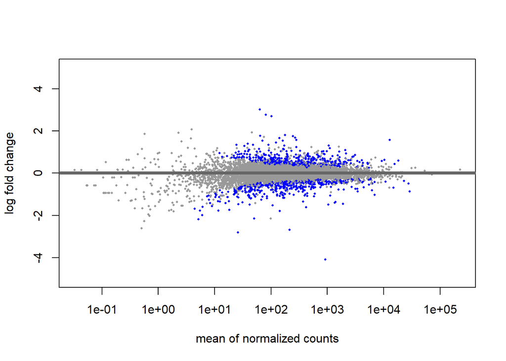

```r
MA_30m <- results(dds_30m,lfcThreshold = 0.05, alpha = 0.05)
         plotMA(MA_30m, ylim=c(-5,5))
```

```r
         print(plotMA)
```

[output not shown]

```r
         summary(MA_30m)
```

```
##
## out of 6775 with nonzero total read count
## adjusted p-value < 0.05
## LFC > 0.05 (up)    : 451, 6.7%
## LFC < -0.05 (down) : 415, 6.1%
## outliers [1]       : 0, 0%
## low counts [2]     : 0, 0%
## (mean count < 0)
## [1] see 'cooksCutoff' argument of ?results
## [2] see 'independentFiltering' argument of ?results
```

```r
resSigind = res_dds30m[ which(res_dds30m$padj < 0.05 & res_dds30m$log2FoldChange > 0), ]
resSigrep = res_dds30m[ which(res_dds30m$padj < 0.05 & res_dds30m$log2FoldChange < 0), ]
resSig = rbind(resSigind, resSigrep)

write.csv(rownames(resSigind), file = "~/Documents/GitHub/CryptoGat201RNASeq_draft/results_deseq/res_dds30m_resSigind.csv")
write.csv(rownames(resSigrep), file = "~/Documents/GitHub/CryptoGat201RNASeq_draft/results_deseq/res_dds30m_resSigrep.csv")
```

## Significant genes at 2 hours

```r
dds_2h <- DESeqDataSetFromMatrix(countData = counts_2h,
                              colData = samplesheet_2h,
                              design = ~ GAT201) %>%
           DESeq()
res_dds2h <- results(dds_2h)
             head(res_dds2h)
```

```
## log2 fold change (MLE): GAT201 No vs Yes
## Wald test p-value: GAT201 No vs Yes
## DataFrame with 6 rows and 6 columns
##             baseMean log2FoldChange     lfcSE      stat      pvalue        padj
##            <numeric>      <numeric> <numeric> <numeric>   <numeric>   <numeric>
## CNAG_00002   508.183      0.0532930 0.1052311  0.506438 6.12549e-01 7.80258e-01
## CNAG_00003   134.779      0.2034436 0.1307140  1.556403 1.19612e-01 2.96647e-01
## CNAG_00004   223.929     -0.0699126 0.1077749 -0.648691 5.16538e-01 7.10858e-01
## CNAG_00005   781.495      0.7415940 0.1417595  5.231353 1.68274e-07 4.54138e-06
## CNAG_00006  1312.043      0.1131508 0.0712003  1.589190 1.12017e-01 2.84091e-01
## CNAG_00007   560.114      0.0226978 0.1018597  0.222834 8.23664e-01 9.07802e-01
```

```r
             sum(res_dds2h$padj <0.05, na.rm = T)
```

```
## [1] 1206
```

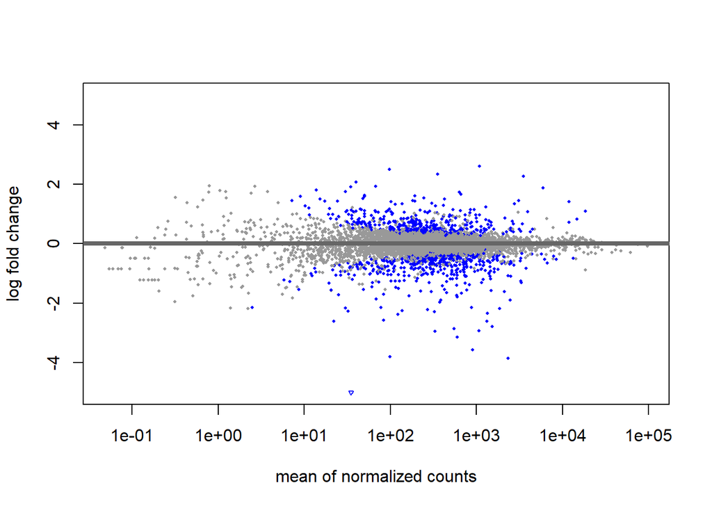

```r
MA_2h <- results(dds_2h,lfcThreshold = 0.05, alpha = 0.05)
         plotMA(MA_2h, ylim=c(-5,5))
```

```r
         print(plotMA)
```

[output not shown]

```r
         summary(MA_2h)
```

```
##
## out of 6774 with nonzero total read count
## adjusted p-value < 0.05
## LFC > 0.05 (up)    : 386, 5.7%
## LFC < -0.05 (down) : 453, 6.7%
## outliers [1]       : 0, 0%
## low counts [2]     : 0, 0%
## (mean count < 0)
## [1] see 'cooksCutoff' argument of ?results
## [2] see 'independentFiltering' argument of ?results
```

```r
resSigind = res_dds2h[ which(res_dds2h$padj < 0.05 & res_dds2h$log2FoldChange > 0), ]
resSigrep = res_dds2h[ which(res_dds2h$padj < 0.05 & res_dds2h$log2FoldChange < 0), ]
resSig = rbind(resSigind, resSigrep)

write.csv(rownames(resSigind), file = "~/Documents/GitHub/CryptoGat201RNASeq_draft/results_deseq/res_dds2h_resSigind.csv")
write.csv(rownames(resSigrep), file = "~/Documents/GitHub/CryptoGat201RNASeq_draft/results_deseq/res_dds2h_resSigrep.csv")
```

## Significant genes at 4 hours

```r
dds_4h <- DESeqDataSetFromMatrix(countData = counts_4h,
                              colData = samplesheet_4h,
                              design = ~ GAT201) %>%
           DESeq()
res_dds4h <- results(dds_4h)
             head(res_dds4h)
```

```
## log2 fold change (MLE): GAT201 No vs Yes
## Wald test p-value: GAT201 No vs Yes
## DataFrame with 6 rows and 6 columns
##             baseMean log2FoldChange     lfcSE      stat      pvalue        padj
##            <numeric>      <numeric> <numeric> <numeric>   <numeric>   <numeric>
## CNAG_00002  301.6972      0.3094943 0.1093916  2.829233 4.66598e-03 1.39095e-02
## CNAG_00003   95.2449     -0.4553357 0.1284694 -3.544314 3.93637e-04 1.72781e-03
## CNAG_00004  152.3694     -0.0890044 0.0954636 -0.932339 3.51162e-01 4.77274e-01
## CNAG_00005  344.5075      0.5629809 0.1021952  5.508878 3.61129e-08 4.79897e-07
## CNAG_00006 1595.4029      0.3088727 0.0699205  4.417483 9.98570e-06 7.18545e-05
## CNAG_00007  433.3385      0.3775899 0.1029696  3.667004 2.45409e-04 1.16324e-03
```

```r
             sum(res_dds4h$padj <0.05, na.rm = T)
```

```
## [1] 2898
```

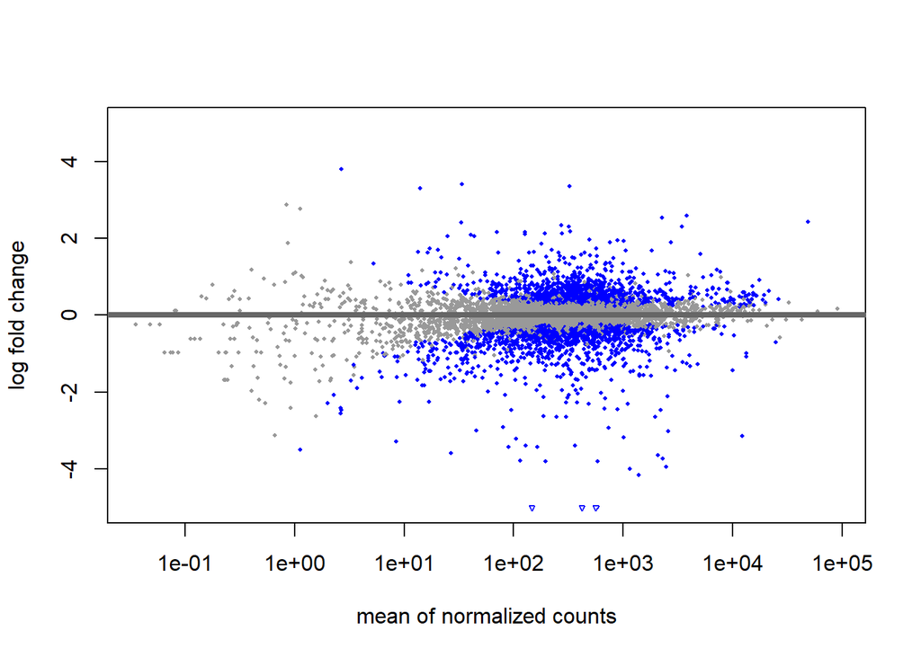

```r
MA_0h <- results(dds_4h,lfcThreshold = 0.05, alpha = 0.05)
         plotMA(MA_4h, ylim=c(-5,5))
```

```r
         print(plotMA)
```

[output not shown]

```r
         summary(MA_4h)
```

```
##
## out of 6764 with nonzero total read count
## adjusted p-value < 0.05
## LFC > 0.05 (up)    : 1178, 17%
## LFC < -0.05 (down) : 1142, 17%
## outliers [1]       : 0, 0%
## low counts [2]     : 0, 0%
## (mean count < 0)
## [1] see 'cooksCutoff' argument of ?results
## [2] see 'independentFiltering' argument of ?results
```

```r
resSigind = res_dds4h[ which(res_dds4h$padj < 0.05 & res_dds4h$log2FoldChange > 0), ]
resSigrep = res_dds4h[ which(res_dds4h$padj < 0.05 & res_dds4h$log2FoldChange < 0), ]
resSig_4h = rbind(resSigind, resSigrep)

write.csv(rownames(resSigind), file = "~/Documents/GitHub/CryptoGat201RNASeq_draft/results_deseq/res_dds4h_resSigind.csv")
write.csv(rownames(resSigrep), file = "~/Documents/GitHub/CryptoGat201RNASeq_draft/results_deseq/res_dds4h_resSigrep.csv")
```

# Gene Annotation

```r
GeneDescription <- readr::read_csv("~/Documents/GitHub/CryptoGat201RNASeq_draft/results_deseq/gene_name_product.csv")
GeneList <- select(GeneDescription, -X1)
head(GeneList)
```

```
## # A tibble: 6 x 2
##   Gene       Product
##   <chr>      <chr>
## 1 CNAG_00002 hypothetical protein
## 2 CNAG_00003 drug transporter
## 3 CNAG_00004 hypothetical protein
## 4 CNAG_00005 TPR repeat-containing protein
## 5 CNAG_00006 prohibitin-2
## 6 CNAG_00007 methionine-tRNA ligase
```

```r
UP4h <- read_csv("~/Documents/GitHub/CryptoGat201RNASeq_draft/results_deseq/res_dds4h_resSigind.csv")
UP4h1 <- select(UP4h, -X1)
UP4hList<- dplyr::rename(UP4h1, Gene = x)
head(UP4hList)
```

```
## # A tibble: 6 x 1
##   Gene
##   <chr>
## 1 CNAG_00002
## 2 CNAG_00005
## 3 CNAG_00006
## 4 CNAG_00007
## 5 CNAG_00012
## 6 CNAG_00013
```

```r
DE4hUP<- dplyr::inner_join(UP4hList,GeneList)
head(DE4hUP)
```

```
## # A tibble: 6 x 2
##   Gene       Product
##   <chr>      <chr>
## 1 CNAG_00002 hypothetical protein
## 2 CNAG_00005 TPR repeat-containing protein
## 3 CNAG_00006 prohibitin-2
## 4 CNAG_00007 methionine-tRNA ligase
## 5 CNAG_00012 hypothetical protein
## 6 CNAG_00013 hypothetical protein, variant 1
```

```r
write.csv(DE4hUP, file = "~/Documents/GitHub/CryptoGat201RNASeq_draft/results_deseq/DE4hUP.csv")
summary(DE4hUP)
```

```
##      Gene             Product
##  Length:1610        Length:1610
##  Class :character   Class :character
##  Mode  :character   Mode  :character
```